# Colab FAQ

For some basic overview and features offered in Colab notebooks, check out: [Overview of Colaboratory Features](https://colab.research.google.com/notebooks/basic_features_overview.ipynb)

You need to use the colab GPU for this assignment by selecting:

> **Runtime** → **Change runtime type** → **Hardware Accelerator: GPU**

# Setup PyTorch

All files will be stored at /content/csc421/a3/ folder

```python
######################################################################
# Setup python environment and change the current working directory
######################################################################
!pip install Pillow
%mkdir -p ./content/csc421/a3/
%cd ./content/csc421/a3
```

```
/content/content/csc421/a3
```

# Helper code

## Utility functions

```python
%matplotlib inline

import os
import pdb
import argparse
import pickle as pkl
from pathlib import Path

from collections import defaultdict

import numpy as np
import matplotlib as mpl
import matplotlib.pyplot as plt
import matplotlib.ticker as ticker

import torch
import torch.nn as nn
import torch.optim as optim
import torch.nn.functional as F
from torch.autograd import Variable

from six.moves.urllib.request import urlretrieve
import tarfile
import pickle
import sys


def get_file(
    fname, origin, untar=False, extract=False, archive_format="auto", cache_dir="data"
):
    datadir = os.path.join(cache_dir)
    if not os.path.exists(datadir):
        os.makedirs(datadir)

    if untar:
        untar_fpath = os.path.join(datadir, fname)
        fpath = untar_fpath + ".tar.gz"
    else:
        fpath = os.path.join(datadir, fname)

    print(fpath)
    if not os.path.exists(fpath):
        print("Downloading data from", origin)

        error_msg = "URL fetch failure on {}: {} -- {}"
        try:
            try:
                urlretrieve(origin, fpath)
            except URLError as e:
                raise Exception(error_msg.format(origin, e.errno, e.reason))
            except HTTPError as e:
                raise Exception(error_msg.format(origin, e.code, e.msg))
        except (Exception, KeyboardInterrupt) as e:
            if os.path.exists(fpath):
                os.remove(fpath)
            raise

    if untar:
        if not os.path.exists(untar_fpath):
            print("Extracting file.")
            with tarfile.open(fpath) as archive:
                archive.extractall(datadir)
        return untar_fpath

    if extract:
        _extract_archive(fpath, datadir, archive_format)

    return fpath


class AttrDict(dict):
    def __init__(self, *args, **kwargs):
        super(AttrDict, self).__init__(*args, **kwargs)
        self.__dict__ = self


def to_var(tensor, cuda):
    """Wraps a Tensor in a Variable, optionally placing it on the GPU.

    Arguments:
        tensor: A Tensor object.
        cuda: A boolean flag indicating whether to use the GPU.

    Returns:
        A Variable object, on the GPU if cuda==True.
    """
    if cuda:
        return Variable(tensor.cuda())
    else:
        return Variable(tensor)


def create_dir_if_not_exists(directory):
    """Creates a directory if it doesn't already exist."""
    if not os.path.exists(directory):
        os.makedirs(directory)


def save_loss_plot(train_losses, val_losses, opts):
    """Saves a plot of the training and validation loss curves."""
    plt.figure()
    plt.plot(range(len(train_losses)), train_losses)
    plt.plot(range(len(val_losses)), val_losses)
    plt.title("BS={}, nhid={}".format(opts.batch_size, opts.hidden_size), fontsize=20)
    plt.xlabel("Epochs", fontsize=16)
    plt.ylabel("Loss", fontsize=16)
    plt.xticks(fontsize=14)
    plt.yticks(fontsize=14)
    plt.tight_layout()
    plt.savefig(os.path.join(opts.checkpoint_path, "loss_plot.pdf"))



def save_loss_comparison_gru(l1, l2, o1, o2, fn, s=500):
    """Plot comparison of training and val loss curves from GRU runs.

    Arguments:
        l1: Tuple of lists containing training / val losses for model 1.
        l2: Tuple of lists containing training / val losses for model 2.
        o1: Options for model 1.
        o2: Options for model 2.
        fn: Output file name.
        s: Number of training iterations to average over.
    """
    mean_l1 = [np.mean(l1[0][i * s : (i + 1) * s]) for i in range(len(l1[0]) // s)]
    mean_l2 = [np.mean(l2[0][i * s : (i + 1) * s]) for i in range(len(l2[0]) // s)]

    plt.figure()

    fig, ax = plt.subplots(1, 2, figsize=(10, 4))

    ax[0].plot(range(len(mean_l1)), mean_l1, label="ds=" + o1.data_file_name)
    ax[0].plot(range(len(mean_l2)), mean_l2, label="ds=" + o2.data_file_name)
    ax[0].title.set_text("Train Loss | GRU Hidden Size = {}".format(o2.hidden_size))

    # Validation losses are assumed to be by epoch
    ax[1].plot(range(len(l1[1])), l1[1], label="ds=" + o1.data_file_name)
    ax[1].plot(range(len(l2[1])), l2[1], label="ds=" + o2.data_file_name)
    ax[1].title.set_text("Val Loss | GRU Hidden Size = {}".format(o2.hidden_size))

    ax[0].set_xlabel("Iterations (x{})".format(s), fontsize=10)
    ax[0].set_ylabel("Loss", fontsize=10)
    ax[1].set_xlabel("Epochs", fontsize=10)
    ax[1].set_ylabel("Loss", fontsize=10)
    ax[0].legend(loc="upper right")
    ax[1].legend(loc="upper right")

    fig.suptitle("GRU Performance by Dataset", fontsize=14)
    plt.tight_layout()
    fig.subplots_adjust(top=0.85)
    plt.legend()

    plt_path = "./loss_plot_{}.pdf".format(fn)
    plt.savefig(plt_path)
    print(f"Plot saved to: {Path(plt_path).resolve()}")


def save_loss_comparison_by_dataset(l1, l2, l3, l4, o1, o2, o3, o4, fn, s=500):
    """Plot comparison of training and validation loss curves from all four
    runs in Part 3, comparing by dataset while holding hidden size constant.

    Models within each pair (l1, l2) and (l3, l4) have the same hidden sizes.

    Arguments:
        l1: Tuple of lists containing training / val losses for model 1.
        l2: Tuple of lists containing training / val losses for model 2.
        l3: Tuple of lists containing training / val losses for model 3.
        l4: Tuple of lists containing training / val losses for model 4.
        o1: Options for model 1.
        o2: Options for model 2.
        o3: Options for model 3.
        o4: Options for model 4.
        fn: Output file name.
        s: Number of training iterations to average over.
    """
    mean_l1 = [np.mean(l1[0][i * s : (i + 1) * s]) for i in range(len(l1[0]) // s)]
    mean_l2 = [np.mean(l2[0][i * s : (i + 1) * s]) for i in range(len(l2[0]) // s)]
    mean_l3 = [np.mean(l3[0][i * s : (i + 1) * s]) for i in range(len(l3[0]) // s)]
    mean_l4 = [np.mean(l4[0][i * s : (i + 1) * s]) for i in range(len(l4[0]) // s)]

    plt.figure()
    fig, ax = plt.subplots(2, 2, figsize=(10, 8))

    ax[0][0].plot(range(len(mean_l1)), mean_l1, label="ds=" + o1.data_file_name)
    ax[0][0].plot(range(len(mean_l2)), mean_l2, label="ds=" + o2.data_file_name)
    ax[0][0].title.set_text(
        "Train Loss | Model Hidden Size = {}".format(o1.hidden_size)
    )

    # Validation losses are assumed to be by epoch
    ax[0][1].plot(range(len(l1[1])), l1[1], label="ds=" + o1.data_file_name)
    ax[0][1].plot(range(len(l2[1])), l2[1], label="ds=" + o2.data_file_name)
    ax[0][1].title.set_text("Val Loss | Model Hidden Size = {}".format(o1.hidden_size))

    ax[1][0].plot(range(len(mean_l3)), mean_l3, label="ds=" + o3.data_file_name)
    ax[1][0].plot(range(len(mean_l4)), mean_l4, label="ds=" + o4.data_file_name)
    ax[1][0].title.set_text(
        "Train Loss | Model Hidden Size = {}".format(o3.hidden_size)
    )

    ax[1][1].plot(range(len(l3[1])), l3[1], label="ds=" + o3.data_file_name)
    ax[1][1].plot(range(len(l4[1])), l4[1], label="ds=" + o4.data_file_name)
    ax[1][1].title.set_text("Val Loss | Model Hidden Size = {}".format(o4.hidden_size))

    for i in range(2):
        ax[i][0].set_xlabel("Iterations (x{})".format(s), fontsize=10)
        ax[i][0].set_ylabel("Loss", fontsize=10)
        ax[i][1].set_xlabel("Epochs", fontsize=10)
        ax[i][1].set_ylabel("Loss", fontsize=10)
        ax[i][0].legend(loc="upper right")
        ax[i][1].legend(loc="upper right")

    fig.suptitle("Performance by Dataset Size", fontsize=16)
    plt.tight_layout()
    fig.subplots_adjust(top=0.9)
    plt.legend()
    plt.savefig("./loss_plot_{}.pdf".format(fn))



def save_loss_comparison_by_hidden(l1, l2, l3, l4, o1, o2, o3, o4, fn, s=500):
    """Plot comparison of training and validation loss curves from all four
    runs in Part 3, comparing by hidden size while holding dataset constant.

    Models within each pair (l1, l3) and (l2, l4) have the same dataset.

    Arguments:
        l1: Tuple of lists containing training / val losses for model 1.
        l2: Tuple of lists containing training / val losses for model 2.
        l3: Tuple of lists containing training / val losses for model 3.
        l4: Tuple of lists containing training / val losses for model 4.
        o1: Options for model 1.
        o2: Options for model 2.
        o3: Options for model 3.
        o4: Options for model 4.
        fn: Output file name.
        s: Number of training iterations to average over.
    """
    mean_l1 = [np.mean(l1[0][i * s : (i + 1) * s]) for i in range(len(l1[0]) // s)]
    mean_l2 = [np.mean(l2[0][i * s : (i + 1) * s]) for i in range(len(l2[0]) // s)]
    mean_l3 = [np.mean(l3[0][i * s : (i + 1) * s]) for i in range(len(l3[0]) // s)]
    mean_l4 = [np.mean(l4[0][i * s : (i + 1) * s]) for i in range(len(l4[0]) // s)]

    plt.figure()
    fig, ax = plt.subplots(2, 2, figsize=(10, 8))

    ax[0][0].plot(range(len(mean_l1)), mean_l1, label="hid_size=" + str(o1.hidden_size))
    ax[0][0].plot(range(len(mean_l3)), mean_l3, label="hid_size=" + str(o3.hidden_size))
    ax[0][0].title.set_text("Train Loss | Dataset = " + o1.data_file_name)

    # Validation losses are assumed to be by epoch
    ax[0][1].plot(range(len(l1[1])), l1[1], label="hid_size=" + str(o1.hidden_size))
    ax[0][1].plot(range(len(l3[1])), l3[1], label="hid_size=" + str(o3.hidden_size))
    ax[0][1].title.set_text("Val Loss | Dataset = " + o1.data_file_name)

    ax[1][0].plot(range(len(mean_l2)), mean_l2, label="hid_size=" + str(o2.hidden_size))
    ax[1][0].plot(range(len(mean_l4)), mean_l4, label="hid_size=" + str(o4.hidden_size))
    ax[1][0].title.set_text("Train Loss | Dataset = " + o3.data_file_name)

    ax[1][1].plot(range(len(l2[1])), l2[1], label="hid_size=" + str(o2.hidden_size))
    ax[1][1].plot(range(len(l4[1])), l4[1], label="hid_size=" + str(o4.hidden_size))
    ax[1][1].title.set_text("Val Loss | Dataset = " + o4.data_file_name)

    for i in range(2):
        ax[i][0].set_xlabel("Iterations (x{})".format(s), fontsize=10)
        ax[i][0].set_ylabel("Loss", fontsize=10)
        ax[i][1].set_xlabel("Epochs", fontsize=10)
        ax[i][1].set_ylabel("Loss", fontsize=10)
        ax[i][0].legend(loc="upper right")
        ax[i][1].legend(loc="upper right")

    fig.suptitle("Performance by Hidden State Size", fontsize=16)
    plt.tight_layout()
    fig.subplots_adjust(top=0.9)
    plt.legend()
    plt.savefig("./loss_plot_{}.pdf".format(fn))



def checkpoint(encoder, decoder, idx_dict, opts):
    """Saves the current encoder and decoder models, along with idx_dict, which
    contains the char_to_index and index_to_char mappings, and the start_token
    and end_token values.
    """
    with open(os.path.join(opts.checkpoint_path, "encoder.pt"), "wb") as f:
        torch.save(encoder, f)

    with open(os.path.join(opts.checkpoint_path, "decoder.pt"), "wb") as f:
        torch.save(decoder, f)

    with open(os.path.join(opts.checkpoint_path, "idx_dict.pkl"), "wb") as f:
        pkl.dump(idx_dict, f)
```

## Data loader

```python
def read_lines(filename):
    """Read a file and split it into lines."""
    lines = open(filename).read().strip().lower().split("\n")
    return lines


def read_pairs(filename):
    """Reads lines that consist of two words, separated by a space.

    Returns:
        source_words: A list of the first word in each line of the file.
        target_words: A list of the second word in each line of the file.
    """
    lines = read_lines(filename)
    source_words, target_words = [], []
    for line in lines:
        line = line.strip()
        if line:
            source, target = line.split()
            source_words.append(source)
            target_words.append(target)
    return source_words, target_words


def all_alpha_or_dash(s):
    """Helper function to check whether a string is alphabetic, allowing dashes '-'."""
    return all(c.isalpha() or c == "-" for c in s)


def filter_lines(lines):
    """Filters lines to consist of only alphabetic characters or dashes "-"."""
    return [line for line in lines if all_alpha_or_dash(line)]


def load_data(file_name):
    """Loads (English, Pig-Latin) word pairs, and creates mappings from characters to indexes."""
    path = "./data/{}.txt".format(file_name)
    source_lines, target_lines = read_pairs(path)

    # Filter lines
    source_lines = filter_lines(source_lines)
    target_lines = filter_lines(target_lines)

    all_characters = set("".join(source_lines)) | set("".join(target_lines))

    # Create a dictionary mapping each character to a unique index
    char_to_index = {
        char: index for (index, char) in enumerate(sorted(list(all_characters)))
    }

    # Add start and end tokens to the dictionary
    start_token = len(char_to_index)
    end_token = len(char_to_index) + 1
    char_to_index["SOS"] = start_token
    char_to_index["EOS"] = end_token

    # Create the inverse mapping, from indexes to characters (used to decode the model's predictions)
    index_to_char = {index: char for (char, index) in char_to_index.items()}

    # Store the final size of the vocabulary
    vocab_size = len(char_to_index)

    line_pairs = list(set(zip(source_lines, target_lines)))  # Python 3

    idx_dict = {
        "char_to_index": char_to_index,
        "index_to_char": index_to_char,
        "start_token": start_token,
        "end_token": end_token,
    }

    return line_pairs, vocab_size, idx_dict


def create_dict(pairs):
    """Creates a mapping { (source_length, target_length): [list of (source, target) pairs]
    This is used to make batches: each batch consists of two parallel tensors, one containing
    all source indexes and the other containing all corresponding target indexes.
    Within a batch, all the source words are the same length, and all the target words are
    the same length.
    """
    unique_pairs = list(set(pairs))  # Find all unique (source, target) pairs

    d = defaultdict(list)
    for (s, t) in unique_pairs:
        d[(len(s), len(t))].append((s, t))

    return d
```

## Training and evaluation code

```python
def string_to_index_list(s, char_to_index, end_token):
    """Converts a sentence into a list of indexes (for each character)."""
    return [char_to_index[char] for char in s] + [
        end_token
    ]  # Adds the end token to each index list


def translate_sentence(sentence, encoder, decoder, idx_dict, opts):
    """Translates a sentence from English to Pig-Latin, by splitting the sentence into
    words (whitespace-separated), running the encoder-decoder model to translate each
    word independently, and then stitching the words back together with spaces between them.
    """
    if idx_dict is None:
        line_pairs, vocab_size, idx_dict = load_data(opts["data_file_name"])
    return " ".join(
        [translate(word, encoder, decoder, idx_dict, opts) for word in sentence.split()]
    )


def translate(input_string, encoder, decoder, idx_dict, opts):
    """Translates a given string from English to Pig-Latin."""

    char_to_index = idx_dict["char_to_index"]
    index_to_char = idx_dict["index_to_char"]
    start_token = idx_dict["start_token"]
    end_token = idx_dict["end_token"]

    max_generated_chars = 20
    gen_string = ""

    indexes = string_to_index_list(input_string, char_to_index, end_token)
    indexes = to_var(
        torch.LongTensor(indexes).unsqueeze(0), opts.cuda
    )  # Unsqueeze to make it like BS = 1

    encoder_annotations, encoder_last_hidden = encoder(indexes)

    decoder_hidden = encoder_last_hidden
    decoder_input = to_var(torch.LongTensor([[start_token]]), opts.cuda)  # For BS = 1
    decoder_inputs = decoder_input

    for i in range(max_generated_chars):
        ## slow decoding, recompute everything at each time
        decoder_outputs, attention_weights = decoder(
            decoder_inputs, encoder_annotations, decoder_hidden
        )

        generated_words = F.softmax(decoder_outputs, dim=2).max(2)[1]
        ni = generated_words.cpu().numpy().reshape(-1)  # LongTensor of size 1
        ni = ni[-1]  # latest output token

        decoder_inputs = torch.cat([decoder_input, generated_words], dim=1)

        if ni == end_token:
            break
        else:
            gen_string = "".join(
                [
                    index_to_char[int(item)]
                    for item in generated_words.cpu().numpy().reshape(-1)
                ]
            )

    return gen_string


def visualize_attention(input_string, encoder, decoder, idx_dict, opts):
    """Generates a heatmap to show where attention is focused in each decoder step."""
    if idx_dict is None:
        line_pairs, vocab_size, idx_dict = load_data(opts["data_file_name"])
    char_to_index = idx_dict["char_to_index"]
    index_to_char = idx_dict["index_to_char"]
    start_token = idx_dict["start_token"]
    end_token = idx_dict["end_token"]

    max_generated_chars = 20
    gen_string = ""

    indexes = string_to_index_list(input_string, char_to_index, end_token)
    indexes = to_var(
        torch.LongTensor(indexes).unsqueeze(0), opts.cuda
    )  # Unsqueeze to make it like BS = 1

    encoder_annotations, encoder_hidden = encoder(indexes)

    decoder_hidden = encoder_hidden
    decoder_input = to_var(torch.LongTensor([[start_token]]), opts.cuda)  # For BS = 1
    decoder_inputs = decoder_input

    produced_end_token = False

    for i in range(max_generated_chars):
        ## slow decoding, recompute everything at each time
        decoder_outputs, attention_weights = decoder(
            decoder_inputs, encoder_annotations, decoder_hidden
        )
        generated_words = F.softmax(decoder_outputs, dim=2).max(2)[1]
        ni = generated_words.cpu().numpy().reshape(-1)  # LongTensor of size 1
        ni = ni[-1]  # latest output token

        decoder_inputs = torch.cat([decoder_input, generated_words], dim=1)

        if ni == end_token:
            break
        else:
            gen_string = "".join(
                [
                    index_to_char[int(item)]
                    for item in generated_words.cpu().numpy().reshape(-1)
                ]
            )

    if isinstance(attention_weights, tuple):
        ## transformer's attention mweights
        attention_weights, self_attention_weights = attention_weights

    all_attention_weights = attention_weights.data.cpu().numpy()

    for i in range(len(all_attention_weights)):
        attention_weights_matrix = all_attention_weights[i].squeeze()
        fig = plt.figure()
        ax = fig.add_subplot(111)
        cax = ax.matshow(attention_weights_matrix, cmap="bone")
        fig.colorbar(cax)

        # Set up axes
        ax.set_yticklabels([""] + list(input_string) + ["EOS"], rotation=90)
        ax.set_xticklabels(
            [""] + list(gen_string) + (["EOS"] if produced_end_token else [])
        )

        # Show label at every tick
        ax.xaxis.set_major_locator(ticker.MultipleLocator(1))
        ax.yaxis.set_major_locator(ticker.MultipleLocator(1))
        # Add title
        plt.xlabel("Attention weights to the source sentence in layer {}".format(i + 1))
        plt.tight_layout()
        plt.grid("off")
        plt.show()

    return gen_string


def compute_loss(data_dict, encoder, decoder, idx_dict, criterion, optimizer, opts):
    """Train/Evaluate the model on a dataset.

    Arguments:
        data_dict: The validation/test word pairs, organized by source and target lengths.
        encoder: An encoder model to produce annotations for each step of the input sequence.
        decoder: A decoder model (with or without attention) to generate output tokens.
        idx_dict: Contains char-to-index and index-to-char mappings, and start & end token indexes.
        criterion: Used to compute the CrossEntropyLoss for each decoder output.
        optimizer: Train the weights if an optimizer is given. None if only evaluate the model.
        opts: The command-line arguments.

    Returns:
        mean_loss: The average loss over all batches from data_dict.
    """
    start_token = idx_dict["start_token"]
    end_token = idx_dict["end_token"]
    char_to_index = idx_dict["char_to_index"]
```

```python
    losses = []
    for key in data_dict:
        input_strings, target_strings = zip(*data_dict[key])
        input_tensors = [
            torch.LongTensor(string_to_index_list(s, char_to_index, end_token))
            for s in input_strings
        ]
        target_tensors = [
            torch.LongTensor(string_to_index_list(s, char_to_index, end_token))
            for s in target_strings
        ]

        num_tensors = len(input_tensors)
        num_batches = int(np.ceil(num_tensors / float(opts.batch_size)))

        for i in range(num_batches):

            start = i * opts.batch_size
            end = start + opts.batch_size

            inputs = to_var(torch.stack(input_tensors[start:end]), opts.cuda)
            targets = to_var(torch.stack(target_tensors[start:end]), opts.cuda)

            # The batch size may be different in each epoch
            BS = inputs.size(0)

            encoder_annotations, encoder_hidden = encoder(inputs)

            # The last hidden state of the encoder becomes the first hidden state of the decoder
            decoder_hidden = encoder_hidden

            start_vector = (
                torch.ones(BS).long().unsqueeze(1) * start_token
            )  # BS x 1 --> 16x1  CHECKED
            decoder_input = to_var(start_vector, opts.cuda)  # BS x 1 --> 16x1  CHECKED

            loss = 0.0

            seq_len = targets.size(1)  # Gets seq_len from BS x seq_len

            decoder_inputs = torch.cat(
                [decoder_input, targets[:, 0:-1]], dim=1
            )  # Gets decoder inputs by shifting the targets to the right

            decoder_outputs, attention_weights = decoder(
                decoder_inputs, encoder_annotations, decoder_hidden
            )
            decoder_outputs_flatten = decoder_outputs.view(-1, decoder_outputs.size(2))
            targets_flatten = targets.view(-1)

            loss = criterion(decoder_outputs_flatten, targets_flatten)

            losses.append(loss.item())

            ## training if an optimizer is provided
            if optimizer:
                # Zero gradients
                optimizer.zero_grad()
                # Compute gradients
                loss.backward()
                # Update the parameters of the encoder and decoder
                optimizer.step()

    return losses


def training_loop(
    train_dict, val_dict, idx_dict, encoder, decoder, criterion, optimizer, opts
):
    """Runs the main training loop; evaluates the model on the val set every epoch.
        * Prints training and val loss each epoch.
        * Prints qualitative translation results each epoch using TEST_SENTENCE
        * Saves an attention map for TEST_WORD_ATTN each epoch
        * Returns loss curves for comparison

    Arguments:
        train_dict: The training word pairs, organized by source and target lengths.
        val_dict: The validation word pairs, organized by source and target lengths.
        idx_dict: Contains char-to-index and index-to-char mappings, and start & end token indexes.
        encoder: An encoder model to produce annotations for each step of the input sequence.
        decoder: A decoder model (with or without attention) to generate output tokens.
        criterion: Used to compute the CrossEntropyLoss for each decoder output.
        optimizer: Implements a step rule to update the parameters of the encoder and decoder.
        opts: The command-line arguments.

    Returns:
        losses: Lists containing training and validation loss curves.
    """

    start_token = idx_dict["start_token"]
    end_token = idx_dict["end_token"]
    char_to_index = idx_dict["char_to_index"]

    loss_log = open(os.path.join(opts.checkpoint_path, "loss_log.txt"), "w")

    best_val_loss = 1e6
    train_losses = []
    val_losses = []

    mean_train_losses = []
    mean_val_losses = []

    early_stopping_counter = 0

    for epoch in range(opts.nepochs):

        optimizer.param_groups[0]["lr"] *= opts.lr_decay

        train_loss = compute_loss(
            train_dict, encoder, decoder, idx_dict, criterion, optimizer, opts
        )
        val_loss = compute_loss(
            val_dict, encoder, decoder, idx_dict, criterion, None, opts
        )

        mean_train_loss = np.mean(train_loss)
        mean_val_loss = np.mean(val_loss)

        if mean_val_loss < best_val_loss:
            checkpoint(encoder, decoder, idx_dict, opts)
            best_val_loss = mean_val_loss
            early_stopping_counter = 0
        else:
            early_stopping_counter += 1

        if early_stopping_counter > opts.early_stopping_patience:
            print(
                "Validation loss has not improved in {} epochs, stopping early".format(
                    opts.early_stopping_patience
                )
            )
            print("Obtained lowest validation loss of: {}".format(best_val_loss))
            return (train_losses, mean_val_losses)

        gen_string = translate_sentence(TEST_SENTENCE, encoder, decoder, idx_dict, opts)
        print(
            "Epoch: {:3d} | Train loss: {:.3f} | Val loss: {:.3f} | Gen: {:20s}".format(
                epoch, mean_train_loss, mean_val_loss, gen_string
            )
        )

        loss_log.write("{} {} {}\n".format(epoch, train_loss, val_loss))
        loss_log.flush()

        train_losses += train_loss
        val_losses += val_loss

        mean_train_losses.append(mean_train_loss)
        mean_val_losses.append(mean_val_loss)

        save_loss_plot(mean_train_losses, mean_val_losses, opts)

    print("Obtained lowest validation loss of: {}".format(best_val_loss))
    return (train_losses, mean_val_losses)


def print_data_stats(line_pairs, vocab_size, idx_dict):
    """Prints example word pairs, the number of data points, and the vocabulary."""
    print("=" * 80)
    print("Data Stats".center(80))
    print("-" * 80)
    for pair in line_pairs[:5]:
        print(pair)
    print("Num unique word pairs: {}".format(len(line_pairs)))
    print("Vocabulary: {}".format(idx_dict["char_to_index"].keys()))
    print("Vocab size: {}".format(vocab_size))
    print("=" * 80)
```

```python
def train(opts):
    line_pairs, vocab_size, idx_dict = load_data(opts["data_file_name"])
    print_data_stats(line_pairs, vocab_size, idx_dict)

    # Split the line pairs into an 80% train and 20% val split
    num_lines = len(line_pairs)
    num_train = int(0.8 * num_lines)
    train_pairs, val_pairs = line_pairs[:num_train], line_pairs[num_train:]

    # Group the data by the lengths of the source and target words, to form batches
    train_dict = create_dict(train_pairs)
    val_dict = create_dict(val_pairs)

    ##########################################################################
    ### Setup: Create Encoder, Decoder, Learning Criterion, and Optimizers ###
    ##########################################################################
    if opts.encoder_type == "rnn":
        encoder = GRUEncoder(
            vocab_size=vocab_size, hidden_size=opts.hidden_size, opts=opts
        )
    elif opts.encoder_type == "transformer":
        encoder = TransformerEncoder(
            vocab_size=vocab_size,
            hidden_size=opts.hidden_size,
            num_layers=opts.num_transformer_layers,
            opts=opts,
        )
    elif opts.encoder_type == "attention":
      encoder = AttentionEncoder(
            vocab_size=vocab_size,
            hidden_size=opts.hidden_size,
            opts=opts,
        )
    else:
        raise NotImplementedError

    if opts.decoder_type == "rnn":
        decoder = RNNDecoder(vocab_size=vocab_size, hidden_size=opts.hidden_size)
    elif opts.decoder_type == "rnn_attention":
        decoder = RNNAttentionDecoder(
            vocab_size=vocab_size,
            hidden_size=opts.hidden_size,
            attention_type=opts.attention_type,
        )
    elif opts.decoder_type == "transformer":
        decoder = TransformerDecoder(
            vocab_size=vocab_size,
            hidden_size=opts.hidden_size,
            num_layers=opts.num_transformer_layers,
        )
    elif opts.encoder_type == "attention":
      decoder = AttentionDecoder(
            vocab_size=vocab_size,
            hidden_size=opts.hidden_size,
        )
    else:
        raise NotImplementedError

    #### setup checkpoint path
    model_name = "h{}-bs{}-{}-{}".format(
        opts.hidden_size, opts.batch_size, opts.decoder_type, opts.data_file_name
    )
    opts.checkpoint_path = model_name
    create_dir_if_not_exists(opts.checkpoint_path)
    ####

    if opts.cuda:
        encoder.cuda()
        decoder.cuda()
        print("Moved models to GPU!")

    criterion = nn.CrossEntropyLoss()
    optimizer = optim.Adam(
        list(encoder.parameters()) + list(decoder.parameters()), lr=opts.learning_rate
    )

    try:
        losses = training_loop(
            train_dict, val_dict, idx_dict, encoder, decoder, criterion, optimizer, opts
        )
    except KeyboardInterrupt:
        print("Exiting early from training.")
        return encoder, decoder, losses

    return encoder, decoder, losses


def print_opts(opts):
    """Prints the values of all command-line arguments."""
    print("=" * 80)
    print("Opts".center(80))
    print("-" * 80)
    for key in opts.__dict__:
        print("{:>30}: {:<30}".format(key, opts.__dict__[key]).center(80))
    print("=" * 80)
```

## Download dataset

```python
######################################################################
# Download Translation datasets
######################################################################
data_fpath = get_file(
    fname="pig_latin_small.txt",
    origin="http://www.cs.toronto.edu/~jba/pig_latin_small.txt",
    untar=False,
)

data_fpath = get_file(
    fname="pig_latin_large.txt",
    origin="http://www.cs.toronto.edu/~jba/pig_latin_large.txt",
    untar=False,
)
```

```
data/pig_latin_small.txt
Downloading data from http://www.cs.toronto.edu/~jba/pig_latin_small.txt
data/pig_latin_large.txt
Downloading data from http://www.cs.toronto.edu/~jba/pig_latin_large.txt
```

# Part 1: Neural machine translation (NMT)

In this section, you will implement a Gated Recurrent Unit (GRU) cell, a common type of recurrent neural network (RNN). The GRU cell is a simplification of the Long Short-Term Memory cell. Therefore, we have provided you with an implemented LSTM cell (`MyLSTMCell`), which you can reference when completing `MyGRUCell`.

```python
class MyLSTMCell(nn.Module):
    def __init__(self, input_size, hidden_size):
        super(MyLSTMCell, self).__init__()

        self.input_size = input_size
        self.hidden_size = hidden_size

        self.Wif = nn.Linear(input_size, hidden_size)
        self.Whf = nn.Linear(hidden_size, hidden_size)

        self.Wii = nn.Linear(input_size, hidden_size)
        self.Whi = nn.Linear(hidden_size, hidden_size)

        self.Wic = nn.Linear(input_size, hidden_size)
        self.Whc = nn.Linear(hidden_size, hidden_size)

        self.Wio = nn.Linear(input_size, hidden_size)
        self.Who = nn.Linear(hidden_size, hidden_size)

    def forward(self, x, h_prev, c_prev):
        """Forward pass of the LSTM computation for one time step.

        Arguments
            x: batch_size x input_size
            h_prev: batch_size x hidden_size
            c_prev: batch_size x hidden_size

        Returns:
            h_new: batch_size x hidden_size
            c_new: batch_size x hidden_size
        """

        f = torch.sigmoid(self.Wif(x) + self.Whf(h_prev))
        i = torch.sigmoid(self.Wii(x) + self.Whi(h_prev))

        c = torch.tanh(self.Wic(x) + self.Whc(h_prev))
        o = torch.sigmoid(self.Wio(x) + self.Who(h_prev))

        c_new = f * c_prev + i * c
        h_new = o * torch.tanh(c_new)

        return h_new, c_new
```

## Step 1: GRU Cell

Please implement the `MyGRUCell` class defined in the next cell.

```python
class MyGRUCell(nn.Module):
    def __init__(self, input_size, hidden_size):
        super(MyGRUCell, self).__init__()

        self.input_size = input_size
        self.hidden_size = hidden_size

        # ------------
        # FILL THIS IN
        # ------------
        # Input linear layers
        self.Wiz = nn.Linear(input_size, hidden_size)
        self.Wir = nn.Linear(input_size, hidden_size)
        self.Wih = nn.Linear(input_size, hidden_size)

        # Hidden linear layers
        self.Whz = nn.Linear(hidden_size, hidden_size)
        self.Whr = nn.Linear(hidden_size, hidden_size)
        self.Whh = nn.Linear(hidden_size, hidden_size)

    def forward(self, x, h_prev):
        """Forward pass of the GRU computation for one time step.

        Arguments
            x: batch_size x input_size
            h_prev: batch_size x hidden_size

        Returns:
            h_new: batch_size x hidden_size
        """

        # ------------
        # FILL THIS IN
        # ------------
        z = torch.sigmoid(self.Wiz(x) + self.Whz(h_prev))
        r = torch.sigmoid(self.Wir(x) + self.Whr(h_prev))
        g = torch.tanh(self.Wih(x) + self.Whh(r * h_prev))
        h_new =  (1 - z) * h_prev + z * g
        return h_new
```

## Step 2: GRU Encoder

The following cells use your `MyGRUCell` implementation to build a recurrent encoder and decoder. Please read the implementations to understand what they do and run the cells before proceeding.

```python
class GRUEncoder(nn.Module):
    def __init__(self, vocab_size, hidden_size, opts):
        super(GRUEncoder, self).__init__()

        self.vocab_size = vocab_size
        self.hidden_size = hidden_size
        self.opts = opts

        self.embedding = nn.Embedding(vocab_size, hidden_size)
        self.gru = MyGRUCell(hidden_size, hidden_size)

    def forward(self, inputs):
        """Forward pass of the encoder RNN.

        Arguments:
            inputs: Input token indexes across a batch for all time steps in the sequence. (batch_size x seq_len)

        Returns:
            annotations: The hidden states computed at each step of the input sequence. (batch_size x seq_len x hidden_size)
            hidden: The final hidden state of the encoder, for each sequence in a batch. (batch_size x hidden_size)
        """

        batch_size, seq_len = inputs.size()
        hidden = self.init_hidden(batch_size)

        encoded = self.embedding(inputs)  # batch_size x seq_len x hidden_size
        annotations = []

        for i in range(seq_len):
            x = encoded[:, i, :]  # Get the current time step, across the whole batch
            hidden = self.gru(x, hidden)
            annotations.append(hidden)

        annotations = torch.stack(annotations, dim=1)
        return annotations, hidden

    def init_hidden(self, bs):
        """Creates a tensor of zeros to represent the initial hidden states
        of a batch of sequences.

        Arguments:
            bs: The batch size for the initial hidden state.

        Returns:
            hidden: An initial hidden state of all zeros. (batch_size x hidden_size)
        """
        return to_var(torch.zeros(bs, self.hidden_size), self.opts.cuda)
```

```python
class RNNDecoder(nn.Module):
    def __init__(self, vocab_size, hidden_size):
        super(RNNDecoder, self).__init__()
        self.vocab_size = vocab_size
        self.hidden_size = hidden_size

        self.embedding = nn.Embedding(vocab_size, hidden_size)
        self.rnn = MyGRUCell(input_size=hidden_size, hidden_size=hidden_size)
        self.out = nn.Linear(hidden_size, vocab_size)

    def forward(self, inputs, annotations, hidden_init):
        """Forward pass of the non-attentional decoder RNN.

        Arguments:
            inputs: Input token indexes across a batch. (batch_size x seq_len)
            annotations: This is not used here. It just maintains consistency with the
                    interface used by the AttentionDecoder class.
            hidden_init: The hidden states from the last step of encoder, across a batch. (batch_size x hidden_size)

        Returns:
            output: Un-normalized scores for each token in the vocabulary, across a batch for all the decoding time steps. (batch_size x decoder_seq_len x vocab_size)
            None
        """
        batch_size, seq_len = inputs.size()
        embed = self.embedding(inputs)  # batch_size x seq_len x hidden_size

        hiddens = []
        h_prev = hidden_init

        for i in range(seq_len):
            x = embed[
                :, i, :
            ]  # Get the current time step input tokens, across the whole batch
            h_prev = self.rnn(x, h_prev)  # batch_size x hidden_size
            hiddens.append(h_prev)

        hiddens = torch.stack(hiddens, dim=1)  # batch_size x seq_len x hidden_size

        output = self.out(hiddens)  # batch_size x seq_len x vocab_size
        return output, None
```

## Step 3: Training and Analysis

Train the encoder-decoder model to perform English --> Pig Latin translation. We will start by training on the smaller dataset.

```python
TEST_SENTENCE = "the air conditioning is working"

rnn_args_s = AttrDict()
args_dict = {
    "data_file_name": "pig_latin_small",
    "cuda": True,
    "nepochs": 50,
    "checkpoint_dir": "checkpoints",
    "learning_rate": 0.005,
    "lr_decay": 0.99,
    "early_stopping_patience": 20,
    "batch_size": 64,
    "hidden_size": 32,
    "encoder_type": "rnn",  # options: rnn / transformer
    "decoder_type": "rnn",  # options: rnn / rnn_attention / transformer
    "attention_type": "",   # options: additive / scaled_dot
}
rnn_args_s.update(args_dict)

print_opts(rnn_args_s)
rnn_encode_s, rnn_decoder_s, rnn_losses_s = train(rnn_args_s)

translated = translate_sentence(
    TEST_SENTENCE, rnn_encode_s, rnn_decoder_s, None, rnn_args_s
)
print("source:\t\t{} \ntranslated:\t{}".format(TEST_SENTENCE, translated))
```

```
================================================================================
                                      Opts
--------------------------------------------------------------------------------
                         data_file_name: pig_latin_small
                                   cuda: 1
                                nepochs: 50
                         checkpoint_dir: checkpoints
                          learning_rate: 0.005
                               lr_decay: 0.99
                early_stopping_patience: 20
                             batch_size: 64
                            hidden_size: 32
                           encoder_type: rnn
                           decoder_type: rnn
                         attention_type:
================================================================================
================================================================================
                                   Data Stats
--------------------------------------------------------------------------------
('receipt', 'eceiptray')
('church', 'urchchay')
('scratch', 'atchscray')
('reach', 'eachray')
('resources', 'esourcesray')
Num unique word pairs: 3198
Vocabulary: dict_keys(['-', 'a', 'b', 'c', 'd', 'e', 'f', 'g', 'h', 'i', 'j', 'k', 'l', 'm', 'n', 'o', 'p', 'q', 'r', 's', 't', 'u', 'v', 'w', 'x', 'y', 'z', 'SOS', 'EOS'])
Vocab size: 29
================================================================================
Moved models to GPU!
Epoch:   0 | Train loss: 2.286 | Val loss: 1.973 | Gen: ay-insay-insay-insay ay-insay-insay-insay intay-insay-insay-in intay-insay-insay-in oonsay-insay-insay-i
Epoch:   1 | Train loss: 1.854 | Val loss: 1.831 | Gen: ensay-ingway-ingway- ay-ay-ingway-ingway- oonsay-ingway-ingway ingway-ingway-ingway oonsay-ingway-ingway
Epoch:   2 | Train loss: 1.719 | Val loss: 1.768 | Gen: edway-ingway-ingway- angway-ingway-ingway oodway-ingway-ingway insway-ingway-ingway oodway-ingway-ingway
Epoch:   3 | Train loss: 1.617 | Val loss: 1.709 | Gen: eday-ationsay-ingway andway-ingway-ingway ooday-ingway-ingway issay-ingway ooday-ingway
Epoch:   4 | Train loss: 1.531 | Val loss: 1.660 | Gen: edway andway-ationsay oodway-ationsay istay oustionsway
Epoch:   5 | Train loss: 1.460 | Val loss: 1.618 | Gen: eway aingway ondgay-ingway istingway oodgay-ationsay
Epoch:   6 | Train loss: 1.403 | Val loss: 1.593 | Gen: eway aingway onsingway-ationsway istingway oodgingway-ationsway
Epoch:   7 | Train loss: 1.335 | Val loss: 1.543 | Gen: eway ainsway-ationsway onsingsway-ationsway istway-ingway oodgay-ingway
Epoch:   8 | Train loss: 1.282 | Val loss: 1.574 | Gen: ehay ainsway-ingway oonssway-ingway-atio istionsay-ingway oodgay-ightway
Epoch:   9 | Train loss: 1.250 | Val loss: 1.539 | Gen: eway asisway onssingsay-ingway issway-ingsay oodgay-ightway
Epoch:  10 | Train loss: 1.199 | Val loss: 1.470 | Gen: eway ainsway onssingsway-atingway istway otay-ightway
```

[output cut: 27 more lines]

```
Epoch:  38 | Train loss: 0.708 | Val loss: 1.417 | Gen: ehay aimpityway ondingityway isway orkway-agsbay
Epoch:  39 | Train loss: 0.700 | Val loss: 1.385 | Gen: ehay aimpingsay ondinghay isway orkway-ightnay
Epoch:  40 | Train loss: 0.687 | Val loss: 1.376 | Gen: ehay aimplay ondingiouslycay isway orkway-ightnay
Epoch:  41 | Train loss: 0.675 | Val loss: 1.461 | Gen: ehay aimway ondingsway issway orkway-agsbay
Epoch:  42 | Train loss: 0.686 | Val loss: 1.372 | Gen: ehay aimpingway ondingiouncay isway orkingway
Epoch:  43 | Train loss: 0.680 | Val loss: 1.365 | Gen: ehay aimpingsay ondingingway isway orkway-ingray
Epoch:  44 | Train loss: 0.652 | Val loss: 1.344 | Gen: ehay aimpingsay ondingingway isway orkway-agsbay
Epoch:  45 | Train loss: 0.630 | Val loss: 1.369 | Gen: ehay aimpingsay ondingingway isway orkway-ightnay
Epoch:  46 | Train loss: 0.620 | Val loss: 1.380 | Gen: ehay aimpingsay ondingingway isway orkingway
Epoch:  47 | Train loss: 0.636 | Val loss: 1.503 | Gen: ehay aimpingpay onjay-ilityway isway orgegray-inway
Epoch:  48 | Train loss: 0.678 | Val loss: 1.380 | Gen: ehay aimpingsay ondingsway isway orkway-ikityway
Epoch:  49 | Train loss: 0.646 | Val loss: 1.375 | Gen: ehay aimpingsay ondingingway isway orkhinggay
Obtained lowest validation loss of: 1.344262980126046
source:		the air conditioning is working
translated:	ehay aimpingsay ondingingway isway orkhinggay
```

Next, we train on the larger dataset. This experiment investigates if increasing dataset size improves model generalization on the validation set.

For a fair comparison, the number of iterations (not number of epochs) for each run should be similar. This is done in a quick and dirty way by adjusting the batch size so approximately the same number of batches is processed per epoch.

```python
TEST_SENTENCE = "the air conditioning is working"

rnn_args_l = AttrDict()
args_dict = {
    "data_file_name": "pig_latin_large",
    "cuda": True,
    "nepochs": 50,
    "checkpoint_dir": "checkpoints",
    "learning_rate": 0.005,
    "lr_decay": 0.99,
    "early_stopping_patience": 10,
    "batch_size": 512,
    "hidden_size": 32,
    "encoder_type": "rnn",  # options: rnn / transformer
    "decoder_type": "rnn",  # options: rnn / rnn_attention / transformer
    "attention_type": "",   # options: additive / scaled_dot
}
rnn_args_l.update(args_dict)

print_opts(rnn_args_l)
rnn_encode_l, rnn_decoder_l, rnn_losses_l = train(rnn_args_l)

translated = translate_sentence(
    TEST_SENTENCE, rnn_encode_l, rnn_decoder_l, None, rnn_args_l
)
print("source:\t\t{} \ntranslated:\t{}".format(TEST_SENTENCE, translated))
```

```
================================================================================
                                      Opts
--------------------------------------------------------------------------------
                         data_file_name: pig_latin_large
                                   cuda: 1
                                nepochs: 50
                         checkpoint_dir: checkpoints
                          learning_rate: 0.005
                               lr_decay: 0.99
                early_stopping_patience: 10
                             batch_size: 512
                            hidden_size: 32
                           encoder_type: rnn
                           decoder_type: rnn
                         attention_type:
================================================================================
================================================================================
                                   Data Stats
--------------------------------------------------------------------------------
('corp', 'orpcay')
('fertile', 'ertilefay')
('file', 'ilefay')
('bake', 'akebay')
('plaque', 'aqueplay')
Num unique word pairs: 22402
Vocabulary: dict_keys(['-', 'a', 'b', 'c', 'd', 'e', 'f', 'g', 'h', 'i', 'j', 'k', 'l', 'm', 'n', 'o', 'p', 'q', 'r', 's', 't', 'u', 'v', 'w', 'x', 'y', 'z', 'SOS', 'EOS'])
Vocab size: 29
================================================================================
Moved models to GPU!
Epoch:   0 | Train loss: 2.294 | Val loss: 2.054 | Gen: ontay-ay-ay ay-ay ontay-ay-ay-ay intay-ay ontay-ay-ay-ay
Epoch:   1 | Train loss: 1.873 | Val loss: 1.875 | Gen: eday allay-ay-ay ontay-ontay-onay-ay insay-ay oray-ontay-onay-ay
Epoch:   2 | Train loss: 1.695 | Val loss: 1.736 | Gen: edway ay ontay-ontay-ay instay ooray-onday
Epoch:   3 | Train loss: 1.564 | Val loss: 1.658 | Gen: edway ay ontersay-onstay-ondw isshessay ortay-onsay-awlay
Epoch:   4 | Train loss: 1.477 | Val loss: 1.590 | Gen: etay asingsay onstay-onday issay orsay-ondway
Epoch:   5 | Train loss: 1.394 | Val loss: 1.580 | Gen: eday-oray-oday ay onsay-intersay-awlay issay ormay-ortay-ondway-a
Epoch:   6 | Train loss: 1.314 | Val loss: 1.487 | Gen: eway ayesay onsay-interway-awlay issay ormimedtay-ondway
Epoch:   7 | Train loss: 1.248 | Val loss: 1.476 | Gen: etay ayessay onstantersay-indway issay ormimedtay-inway
Epoch:   8 | Train loss: 1.207 | Val loss: 1.524 | Gen: etay ayispay onstersay-indway-awl say ormpitionssay
Epoch:   9 | Train loss: 1.171 | Val loss: 1.416 | Gen: etsay aysway onstaningedtay isssay impkingway
Epoch:  10 | Train loss: 1.113 | Val loss: 1.374 | Gen: ethay ayisway onstersay-inway-awla isssay orkestingsway
```

[output cut: 27 more lines]

```
Epoch:  38 | Train loss: 0.631 | Val loss: 1.067 | Gen: ethay airway onditingway isway imorway
Epoch:  39 | Train loss: 0.633 | Val loss: 1.030 | Gen: ethay airway onditingway isway oritionway
Epoch:  40 | Train loss: 0.632 | Val loss: 1.136 | Gen: ethay airway onditingday isway ominay
Epoch:  41 | Train loss: 0.648 | Val loss: 1.034 | Gen: ethay airyway onditinglay issway oritionway
Epoch:  42 | Train loss: 0.623 | Val loss: 1.055 | Gen: ethay airway onditingay-aysday isway orikinay
Epoch:  43 | Train loss: 0.623 | Val loss: 1.141 | Gen: ethay airway onditingday iway oritionway
Epoch:  44 | Train loss: 0.629 | Val loss: 1.003 | Gen: ethay airaway onditingday isway ominymay
Epoch:  45 | Train loss: 0.611 | Val loss: 1.163 | Gen: ethay aireway onditinglay-ayday isway ominymay
Epoch:  46 | Train loss: 0.654 | Val loss: 1.067 | Gen: ethay airyway onditinglay isway iriknay
Epoch:  47 | Train loss: 0.622 | Val loss: 0.989 | Gen: ethay airay onditinglay isway omintyway
Epoch:  48 | Train loss: 0.585 | Val loss: 1.009 | Gen: ethay airay onditingway isway oritionay
Epoch:  49 | Train loss: 0.562 | Val loss: 1.026 | Gen: ethay airay onditingway isway ominymay
Obtained lowest validation loss of: 0.9894848461449146
source:		the air conditioning is working
translated:	ethay airay onditingway isway ominymay
```

The code below plots the training and validation losses of each model, as a function of the number of gradient descent iterations. Are there significant differences in the validation performance of each model? (see follow-up questions in handout)

## Part 1 Question 1 - *Code a GRU Cell* :

Does either model perform significantly better?

Why might this be the case?

- The reason is rather obvious, which that a larger data set yields lower variance, lower loss, more accurate calculations when training our model and hence better performance.

```
Plot saved to: /content/content/csc421/a3/loss_plot_gru.pdf
```

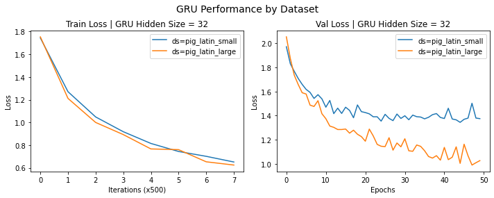

```python
save_loss_comparison_gru(rnn_losses_s, rnn_losses_l, rnn_args_s, rnn_args_l, "gru")
```

Select best performing model, and try translating different sentences by changing the variable TEST_SENTENCE. Identify a failure mode and briefly describe it (see follow-up questions in handout).

## Part 1 Question 2 - *Identify failure modes* :

TEST_SENTENCE = " i had a lecture at the convocation hall back in october "

```python
best_encoder = rnn_encode_l  # Replace with rnn_encode_s or rnn_encode_l
best_decoder = rnn_decoder_l # Replace with rnn_decoder_s or rnn_decoder_l
best_args = rnn_args_l     # Replace with rnn_args_s or rnn_args_l

TEST_SENTENCE = "i had a lecture at the convocation hall back in october"
translated = translate_sentence(
    TEST_SENTENCE, best_encoder, best_decoder, None, best_args
)
print("source:\t\t{} \ntranslated:\t{}".format(TEST_SENTENCE, translated))
```

```
source:		i had a lecture at the convocation hall back in october
translated:	iway adgay away ecteray atay ethay oncotionay-ayday allway ackway-aysday inway octorday
```

## Part 1 Question 3 - *Comparing complexity* :

What are the total number of parameters of the LSTM encoder?

- 4 *K* H * (D + H)

What are the total number of parameters of the GRU encoder?

- 3 *K* H * (D + H)

# Part 2: Attention mechanisms

## Step 1: Additive attention

In the next cell, the [additive attention](https://paperswithcode.com/method/additive-attention) mechanism has been implemented for you. Please take a momement to read through it and understand what it is doing. See the assignment handouts for details.

```python
class AdditiveAttention(nn.Module):
    def __init__(self, hidden_size):
        super(AdditiveAttention, self).__init__()

        self.hidden_size = hidden_size

        # A two layer fully-connected network
        # hidden_size * 2 --> hidden_size, ReLU, hidden_size --> 1
        self.attention_network = nn.Sequential(
            nn.Linear(hidden_size * 2, hidden_size),
            nn.ReLU(),
            nn.Linear(hidden_size, 1),
        )

        self.softmax = nn.Softmax(dim=1)

    def forward(self, queries, keys, values):
        """The forward pass of the additive attention mechanism.

        Arguments:
            queries: The current decoder hidden state. (batch_size x hidden_size)
            keys: The encoder hidden states for each step of the input sequence. (batch_size x seq_len x hidden_size)
            values: The encoder hidden states for each step of the input sequence. (batch_size x seq_len x hidden_size)

        Returns:
            context: weighted average of the values (batch_size x 1 x hidden_size)
            attention_weights: Normalized attention weights for each encoder hidden state. (batch_size x seq_len x 1)

            The attention_weights must be a softmax weighting over the seq_len annotations.
        """
        batch_size = keys.size(0)
        expanded_queries = queries.view(batch_size, -1, self.hidden_size).expand_as(
            keys
        )
        concat_inputs = torch.cat([expanded_queries, keys], dim=2)
        unnormalized_attention = self.attention_network(concat_inputs)
        attention_weights = self.softmax(unnormalized_attention)
        context = torch.bmm(attention_weights.transpose(2, 1), values)
        return context, attention_weights
```

## Step 2: RNN + additive attention

In the next cell, a modification of our `RNNDecoder` that makes use of an additive attention mechanism as been implemented for your. Please take a momement to read through it and understand what it is doing. See the assignment handouts for details.

```python
class RNNAttentionDecoder(nn.Module):
    def __init__(self, vocab_size, hidden_size, attention_type="scaled_dot"):
        super(RNNAttentionDecoder, self).__init__()
        self.vocab_size = vocab_size
        self.hidden_size = hidden_size

        self.embedding = nn.Embedding(vocab_size, hidden_size)

        self.rnn = MyGRUCell(input_size=hidden_size * 2, hidden_size=hidden_size)
        if attention_type == "additive":
            self.attention = AdditiveAttention(hidden_size=hidden_size)
        elif attention_type == "scaled_dot":
            self.attention = ScaledDotAttention(hidden_size=hidden_size)

        self.out = nn.Linear(hidden_size, vocab_size)

    def forward(self, inputs, annotations, hidden_init):
        """Forward pass of the attention-based decoder RNN.

        Arguments:
            inputs: Input token indexes across a batch for all the time step. (batch_size x decoder_seq_len)
            annotations: The encoder hidden states for each step of the input.
                         sequence. (batch_size x seq_len x hidden_size)
            hidden_init: The final hidden states from the encoder, across a batch. (batch_size x hidden_size)

        Returns:
            output: Un-normalized scores for each token in the vocabulary, across a batch for all the decoding time steps. (batch_size x decoder_seq_len x vocab_size)
            attentions: The stacked attention weights applied to the encoder annotations (batch_size x encoder_seq_len x decoder_seq_len)
        """

        batch_size, seq_len = inputs.size()
        embed = self.embedding(inputs)  # batch_size x seq_len x hidden_size

        hiddens = []
        attentions = []
        h_prev = hidden_init

        for i in range(seq_len):
            embed_current = embed[
                :, i, :
            ]  # Get the current time step, across the whole batch
            context, attention_weights = self.attention(
                h_prev, annotations, annotations
            )  # batch_size x 1 x hidden_size
            embed_and_context = torch.cat(
                [embed_current, context.squeeze(1)], dim=1
            )  # batch_size x (2*hidden_size)
            h_prev = self.rnn(embed_and_context, h_prev)  # batch_size x hidden_size

            hiddens.append(h_prev)
            attentions.append(attention_weights)

        hiddens = torch.stack(hiddens, dim=1)  # batch_size x seq_len x hidden_size
        attentions = torch.cat(attentions, dim=2)  # batch_size x seq_len x seq_len

        output = self.out(hiddens)  # batch_size x seq_len x vocab_size
        return output, attentions
```

## Step 3: Training and analysis (with additive attention)

Now, run the following cell to train our recurrent encoder-decoder model with additive attention. How does it perform compared to the recurrent encoder-decoder model without attention?

```python
TEST_SENTENCE = "the air conditioning is working"

rnn_attn_args = AttrDict()
args_dict = {
    "data_file_name": "pig_latin_small",
    "cuda": True,
    "nepochs": 50,
    "checkpoint_dir": "checkpoints",
    "learning_rate": 0.005,
    "lr_decay": 0.99,
    "early_stopping_patience": 10,
    "batch_size": 64,
    "hidden_size": 64,
    "encoder_type": "rnn",            # options: rnn / transformer
    "decoder_type": "rnn_attention",  # options: rnn / rnn_attention / transformer
    "attention_type": "additive",     # options: additive / scaled_dot
}
rnn_attn_args.update(args_dict)

print_opts(rnn_attn_args)
rnn_attn_encoder, rnn_attn_decoder, rnn_attn_losses = train(rnn_attn_args)

translated = translate_sentence(
    TEST_SENTENCE, rnn_attn_encoder, rnn_attn_decoder, None, rnn_attn_args
)
print("source:\t\t{} \ntranslated:\t{}".format(TEST_SENTENCE, translated))
```

```
================================================================================
                                      Opts
--------------------------------------------------------------------------------
                         data_file_name: pig_latin_small
                                   cuda: 1
                                nepochs: 50
                         checkpoint_dir: checkpoints
                          learning_rate: 0.005
                               lr_decay: 0.99
                early_stopping_patience: 10
                             batch_size: 64
                            hidden_size: 64
                           encoder_type: rnn
                           decoder_type: rnn_attention
                         attention_type: additive
================================================================================
================================================================================
                                   Data Stats
--------------------------------------------------------------------------------
('receipt', 'eceiptray')
('church', 'urchchay')
('scratch', 'atchscray')
('reach', 'eachray')
('resources', 'esourcesray')
Num unique word pairs: 3198
Vocabulary: dict_keys(['-', 'a', 'b', 'c', 'd', 'e', 'f', 'g', 'h', 'i', 'j', 'k', 'l', 'm', 'n', 'o', 'p', 'q', 'r', 's', 't', 'u', 'v', 'w', 'x', 'y', 'z', 'SOS', 'EOS'])
Vocab size: 29
================================================================================
Moved models to GPU!
Epoch:   0 | Train loss: 1.973 | Val loss: 1.737 | Gen: otay-ay-ay-ay-ay-ay- isay-arway-irray-arw ingtay-ingway-ingway isssay-issay-issay-i ingsay-ingredgay-ing
Epoch:   1 | Train loss: 1.455 | Val loss: 1.445 | Gen: etay aray-aray-aray-aray- ingedtay issay ingrengray-angingway
Epoch:   2 | Train loss: 1.144 | Val loss: 1.272 | Gen: etay arway ingingsay-ingsay isisisisifisway orkgsray
Epoch:   3 | Train loss: 0.935 | Val loss: 1.262 | Gen: etay irway-iway ingway-ingway isway inghray
Epoch:   4 | Train loss: 0.805 | Val loss: 1.074 | Gen: ethay airay ondiondionitionday isway oray-ingway-ingway
Epoch:   5 | Train loss: 0.641 | Val loss: 1.084 | Gen: etay arifay ondonditonday-ingion isway orkignghay-igngingda
Epoch:   6 | Train loss: 0.512 | Val loss: 0.875 | Gen: ethay ariway-imay ondingingcay isway orkningway
Epoch:   7 | Train loss: 0.402 | Val loss: 0.941 | Gen: ehay arrway-arway ondontingccay isway orkwingway-ingway
Epoch:   8 | Train loss: 0.338 | Val loss: 0.583 | Gen: ethay airway onditioncay isway orkingway
Epoch:   9 | Train loss: 0.239 | Val loss: 0.609 | Gen: ehay airway-away ondditiongway isway orkingway
Epoch:  10 | Train loss: 0.215 | Val loss: 0.600 | Gen: ethay airway-awway onditiongway isway oovingway
```

[output cut: 20 more lines]

```
Epoch:  31 | Train loss: 0.018 | Val loss: 0.249 | Gen: ethay airway onditioningcay isway orkingway
Epoch:  32 | Train loss: 0.009 | Val loss: 0.265 | Gen: ethay airway onditioningcay isway orkingway
Epoch:  33 | Train loss: 0.005 | Val loss: 0.275 | Gen: ethay airway onditionicingcay isway orkingway
Epoch:  34 | Train loss: 0.004 | Val loss: 0.269 | Gen: ethay airway onditioningcay isway orkingway
Epoch:  35 | Train loss: 0.003 | Val loss: 0.265 | Gen: ethay airway onditioningcay isway orkingway
Epoch:  36 | Train loss: 0.002 | Val loss: 0.262 | Gen: ethay airway onditioningcay isway orkingway
Epoch:  37 | Train loss: 0.002 | Val loss: 0.261 | Gen: ethay airway onditioningcay isway orkingway
Epoch:  38 | Train loss: 0.002 | Val loss: 0.261 | Gen: ethay airway onditioningcay isway orkingway
Epoch:  39 | Train loss: 0.002 | Val loss: 0.261 | Gen: ethay airway onditioningcay isway orkingway
Epoch:  40 | Train loss: 0.002 | Val loss: 0.262 | Gen: ethay airway onditioningcay isway orkingway
Epoch:  41 | Train loss: 0.001 | Val loss: 0.262 | Gen: ethay airway onditioningcay isway orkingway
Validation loss has not improved in 10 epochs, stopping early
Obtained lowest validation loss of: 0.24941011262440904
source:		the air conditioning is working
translated:	ethay airway onditioningcay isway orkingway
```

```python
TEST_SENTENCE = "the air conditioning is working"
translated = translate_sentence(
    TEST_SENTENCE, rnn_attn_encoder, rnn_attn_decoder, None, rnn_attn_args
)
print("source:\t\t{} \ntranslated:\t{}".format(TEST_SENTENCE, translated))
```

```
source:		the air conditioning is working
translated:	ethay airway onditioningcay isway orkingway
```

## Part 2.1 Question 3:

The training speeds of RNN + attention takes a bit longer (2min 58 secs) than RNN without attention (2min 26 secs). This could be due to the training complexity of RNN is $t \times k^{2} \times d$, whereas RNN + attention is $t^{2} \times k^{2} \times d$, where t: sequence length, d: # layers and k: # nuerons at each layer. However, the accuracy of the translated sentence is much higher for RNN + attention than RNN given that the validation loss is much smaller.

## Step 4: Implement scaled dot-product attention

In the next cell, you will implement the [scaled dot-product attention](https://paperswithcode.com/method/scaled) mechanism. See the assignment handouts for details.

```python
class ScaledDotAttention(nn.Module):
    def __init__(self, hidden_size):
        super(ScaledDotAttention, self).__init__()

        self.hidden_size = hidden_size

        self.Q = nn.Linear(hidden_size, hidden_size)
        self.K = nn.Linear(hidden_size, hidden_size)
        self.V = nn.Linear(hidden_size, hidden_size)
        self.softmax = nn.Softmax(dim=1)
        self.scaling_factor = torch.rsqrt(
            torch.tensor(self.hidden_size, dtype=torch.float)
        )

    def forward(self, queries, keys, values):
        """The forward pass of the scaled dot attention mechanism.

        Arguments:
            queries: The current decoder hidden state, 2D or 3D tensor. (batch_size x (k) x hidden_size)
            keys: The encoder hidden states for each step of the input sequence. (batch_size x seq_len x hidden_size)
            values: The encoder hidden states for each step of the input sequence. (batch_size x seq_len x hidden_size)

        Returns:
            context: weighted average of the values (batch_size x k x hidden_size)
            attention_weights: Normalized attention weights for each encoder hidden state. (batch_size x seq_len x k)

            The output must be a softmax weighting over the seq_len annotations.
        """

        # ------------
        # FILL THIS IN
        # ------------
        batch_size = keys.size(0)
        q = self.Q(queries).view(batch_size, -1, self.hidden_size)
        k = self.K(keys)
        v = self.V(values)
        unnormalized_attention = torch.bmm(k, q.transpose(2,1)) * self.scaling_factor
        attention_weights = self.softmax(unnormalized_attention)
        context = torch.bmm(attention_weights.transpose(2,1), v)

        return context, attention_weights
```

## Step 5: Implement causal dot-product Attention

Now, implement the casual scaled dot-product attention mechanism. It will be very similar to your implementation for `ScaledDotAttention`. The additional step is to mask out the attention to future timesteps so this attention mechanism can be used in a decoder. See the assignment handouts for details.

```python
class CausalScaledDotAttention(nn.Module):
    def __init__(self, hidden_size):
        super(CausalScaledDotAttention, self).__init__()

        self.hidden_size = hidden_size
        self.neg_inf = torch.tensor(-1e7)

        self.Q = nn.Linear(hidden_size, hidden_size)
        self.K = nn.Linear(hidden_size, hidden_size)
        self.V = nn.Linear(hidden_size, hidden_size)
        self.softmax = nn.Softmax(dim=1)
        self.scaling_factor = torch.rsqrt(
            torch.tensor(self.hidden_size, dtype=torch.float)
        )

    def forward(self, queries, keys, values):
        """The forward pass of the scaled dot attention mechanism.

        Arguments:
            queries: The current decoder hidden state, 2D or 3D tensor. (batch_size x (k) x hidden_size)
            keys: The encoder hidden states for each step of the input sequence. (batch_size x seq_len x hidden_size)
            values: The encoder hidden states for each step of the input sequence. (batch_size x seq_len x hidden_size)

        Returns:
            context: weighted average of the values (batch_size x k x hidden_size)
            attention_weights: Normalized attention weights for each encoder hidden state. (batch_size x seq_len x k)

            The output must be a softmax weighting over the seq_len annotations.
        """

        # ------------
        # FILL THIS IN
        # ------------
        batch_size = keys.size(0)
        q = self.Q(queries).view(batch_size, -1, self.hidden_size)
        k = self.K(keys)
        v = self.V(values)
        unnormalized_attention = torch.bmm(k, q.transpose(2,1)) * self.scaling_factor
        mask = torch.tril(torch.ones_like(unnormalized_attention) * self.neg_inf, diagonal=-1)
        attention_weights = self.softmax(unnormalized_attention + mask)
        context = torch.bmm(attention_weights.transpose(2,1), v)
        return context, attention_weights
```

## Step 6: Attention encoder and decoder

The following cells provide an implementation of an encoder and decoder that use a single `ScaledDotAttention` block. Please read through them to understand what they are doing.

```python
class AttentionEncoder(nn.Module):
    def __init__(self, vocab_size, hidden_size, opts):
        super(AttentionEncoder, self).__init__()

        self.vocab_size = vocab_size
        self.hidden_size = hidden_size
        self.opts = opts

        self.embedding = nn.Embedding(vocab_size, hidden_size)

        self.self_attention = ScaledDotAttention(
                    hidden_size=hidden_size,
                )

        self.attention_mlp = nn.Sequential(
                                nn.Linear(hidden_size, hidden_size),
                                nn.ReLU(),
                              )

    def forward(self, inputs):
        """Forward pass of the encoder scaled dot attention.

        Arguments:
            inputs: Input token indexes across a batch for all time steps in the sequence. (batch_size x seq_len)

        Returns:
            annotations: The hidden states computed at each step of the input sequence. (batch_size x seq_len x hidden_size)
            None: Used to conform to standard encoder return signature.
        """
        batch_size, seq_len = inputs.size()

        encoded = self.embedding(inputs)  # batch_size x seq_len x hidden_size

        annotations = encoded
        new_annotations, self_attention_weights = self.self_attention(
            annotations, annotations, annotations
        )  # batch_size x seq_len x hidden_size
        residual_annotations = annotations + new_annotations
        new_annotations = self.attention_mlp(residual_annotations)
        annotations = residual_annotations + new_annotations

        return annotations, None
```

```python
class AttentionDecoder(nn.Module):
    def __init__(self, vocab_size, hidden_size):
        super(AttentionDecoder, self).__init__()
        self.vocab_size = vocab_size
        self.hidden_size = hidden_size

        self.embedding = nn.Embedding(vocab_size, hidden_size)

        self.self_attention = CausalScaledDotAttention(
                                hidden_size=hidden_size,
                                )

        self.decoder_attention = ScaledDotAttention(
                                  hidden_size=hidden_size,
                                  )

        self.attention_mlp = nn.Sequential(
                                nn.Linear(hidden_size, hidden_size),
                                nn.ReLU(),
                              )

        self.out = nn.Linear(hidden_size, vocab_size)


    def forward(self, inputs, annotations, hidden_init):
        """Forward pass of the attention-based decoder RNN.

        Arguments:
            inputs: Input token indexes across a batch for all the time step. (batch_size x decoder_seq_len)
            annotations: The encoder hidden states for each step of the input.
                         sequence. (batch_size x seq_len x hidden_size)
            hidden_init: Not used in the transformer decoder
        Returns:
            output: Un-normalized scores for each token in the vocabulary, across a batch for all the decoding time steps. (batch_size x decoder_seq_len x vocab_size)
            attentions: The stacked attention weights applied to the encoder annotations (batch_size x encoder_seq_len x decoder_seq_len)
        """

        batch_size, seq_len = inputs.size()
        embed = self.embedding(inputs)  # batch_size x seq_len x hidden_size

        encoder_attention_weights_list = []
        self_attention_weights_list = []
        contexts = embed
        new_contexts, self_attention_weights = self.self_attention(
            contexts, contexts, contexts
        )  # batch_size x seq_len x hidden_size
        residual_contexts = contexts + new_contexts
        new_contexts, encoder_attention_weights = self.decoder_attention(
            residual_contexts, annotations, annotations
        )  # batch_size x seq_len x hidden_size
        residual_contexts = residual_contexts + new_contexts
        new_contexts = self.attention_mlp(residual_contexts)
        contexts = residual_contexts + new_contexts

        encoder_attention_weights_list.append(encoder_attention_weights)
        self_attention_weights_list.append(self_attention_weights)

        output = self.out(contexts)
        encoder_attention_weights = torch.stack(encoder_attention_weights_list)
        self_attention_weights = torch.stack(self_attention_weights_list)

        return output, (encoder_attention_weights, self_attention_weights)
```

## Step 7: Training and analysis (single scaled dot-product attention block)

Now, train the following model, with an encoder and decoder each composed a single `ScaledDotAttention` block.

```python
TEST_SENTENCE = "the air conditioning is working"

attention_args_s = AttrDict()
args_dict = {
    "data_file_name": "pig_latin_small",
    "cuda": True,
    "nepochs": 100,
    "checkpoint_dir": "checkpoints",
    "learning_rate": 5e-4,
    "early_stopping_patience": 100,
    "lr_decay": 0.99,
    "batch_size": 64,
    "hidden_size": 32,
    "encoder_type": "attention",
    "decoder_type": "attention",  # options: rnn / rnn_attention / attention / transformer
}
attention_args_s.update(args_dict)
print_opts(attention_args_s)

attention_encoder_s, attention_decoder_s, attention_losses_s = train(attention_args_s)

translated = translate_sentence(
    TEST_SENTENCE, attention_encoder_s, attention_decoder_s, None, attention_args_s
)
print("source:\t\t{} \ntranslated:\t{}".format(TEST_SENTENCE, translated))
```

```
================================================================================
                                      Opts
--------------------------------------------------------------------------------
                         data_file_name: pig_latin_small
                                   cuda: 1
                                nepochs: 100
                         checkpoint_dir: checkpoints
                          learning_rate: 0.0005
                early_stopping_patience: 100
                               lr_decay: 0.99
                             batch_size: 64
                            hidden_size: 32
                           encoder_type: attention
                           decoder_type: attention
================================================================================
================================================================================
                                   Data Stats
--------------------------------------------------------------------------------
('receipt', 'eceiptray')
('church', 'urchchay')
('scratch', 'atchscray')
('reach', 'eachray')
('resources', 'esourcesray')
Num unique word pairs: 3198
Vocabulary: dict_keys(['-', 'a', 'b', 'c', 'd', 'e', 'f', 'g', 'h', 'i', 'j', 'k', 'l', 'm', 'n', 'o', 'p', 'q', 'r', 's', 't', 'u', 'v', 'w', 'x', 'y', 'z', 'SOS', 'EOS'])
Vocab size: 29
================================================================================
Moved models to GPU!
Epoch:   0 | Train loss: 3.005 | Val loss: 2.484 | Gen: ay ay ay y ay
Epoch:   1 | Train loss: 2.336 | Val loss: 2.136 | Gen: eday iy ontintintintintintin iy ontintintintintintin
Epoch:   2 | Train loss: 2.104 | Val loss: 1.988 | Gen: eday iray intintintintintintin isisisay inenay
Epoch:   3 | Train loss: 1.983 | Val loss: 1.899 | Gen: eday iray intintintintintintin isisississississsiss inay
Epoch:   4 | Train loss: 1.897 | Val loss: 1.833 | Gen: eday iray ontintintintintintin isisssisssisssisssis ingingingingingingsa
Epoch:   5 | Train loss: 1.824 | Val loss: 1.778 | Gen: eday iray ontinconconconconcon ississsissssisssisss ingingingsay
Epoch:   6 | Train loss: 1.758 | Val loss: 1.726 | Gen: eday iray ontintintintintintin ississssisssiay ingingingsay
Epoch:   7 | Train loss: 1.695 | Val loss: 1.674 | Gen: eday iray ongingingtingway ississssiay ingingsay
Epoch:   8 | Train loss: 1.633 | Val loss: 1.627 | Gen: eday iraray ongingingway ississssiay inginghay
Epoch:   9 | Train loss: 1.575 | Val loss: 1.580 | Gen: eday iray ongingingway ississsay inginghay
Epoch:  10 | Train loss: 1.523 | Val loss: 1.535 | Gen: ehay iray ongingingngay ississay onginghinghay
Epoch:  11 | Train loss: 1.477 | Val loss: 1.495 | Gen: ehay iray ongingingngway issisay onginghinghay
```

[output cut: 76 more lines]

```
Epoch:  88 | Train loss: 0.780 | Val loss: 1.044 | Gen: ethay iray oniongmiongway isway orkingway
Epoch:  89 | Train loss: 0.778 | Val loss: 1.036 | Gen: ethay ariay oniongmiongway isway orkingway
Epoch:  90 | Train loss: 0.775 | Val loss: 1.041 | Gen: ethay iray oniongmiongway isway orkingway
Epoch:  91 | Train loss: 0.773 | Val loss: 1.032 | Gen: ethay ariay oniongmiongway isway orkingway
Epoch:  92 | Train loss: 0.770 | Val loss: 1.037 | Gen: ethay iray oniongmiongway isway orkingway
Epoch:  93 | Train loss: 0.769 | Val loss: 1.030 | Gen: ethay ariay oniongmiongway isway orkingway
Epoch:  94 | Train loss: 0.766 | Val loss: 1.034 | Gen: ethay iray oniongmiongway isway orkingway
Epoch:  95 | Train loss: 0.764 | Val loss: 1.027 | Gen: ethay ariay oniongmiongway isway orkingway
Epoch:  96 | Train loss: 0.761 | Val loss: 1.032 | Gen: ethay iray oniongmiongway isway orkingway
Epoch:  97 | Train loss: 0.760 | Val loss: 1.024 | Gen: ethay ariay oniongmiongway isway orkingway
Epoch:  98 | Train loss: 0.757 | Val loss: 1.029 | Gen: ethay iray oniongmiongway isway orkingway
Epoch:  99 | Train loss: 0.756 | Val loss: 1.022 | Gen: ethay ariay oniongmiongway isway orkingway
Obtained lowest validation loss of: 1.0221946396537729
source:		the air conditioning is working
translated:	ethay ariay oniongmiongway isway orkingway
```

## Part 2.2 Question 3:

The ScaledDotAttention scale the un-normalized attention weights by the square root of the vector length and the training complexity k facotr more than the RNN + attention where k: # neurons at each layer. Hence, the ScaledDotAttention is much faster and space-efficient than RNNAttention. In terms of the accuracy of translation of the tested senetcnce, looking at the validation loss between ScaledDotAttention and RNNAttention, RNNAttention yields a lower validation loss and higher accuracy. Although ScaledDotAttention is much faster and space-efficient than RNNAttention , RNNAttention, which has more # neurons at each layer, yields a better accuracy.

## Step 8: Transformer encoder and decoder

The following cells provide an implementation of the transformer encoder and decoder that use your `ScaledDotAttention` and `CausalScaledDotAttention`. Please read through them to understand what they are doing.

```python
class TransformerEncoder(nn.Module):
    def __init__(self, vocab_size, hidden_size, num_layers, opts):
        super(TransformerEncoder, self).__init__()

        self.vocab_size = vocab_size
        self.hidden_size = hidden_size
        self.num_layers = num_layers
        self.opts = opts

        self.embedding = nn.Embedding(vocab_size, hidden_size)

        self.self_attentions = nn.ModuleList(
            [
                ScaledDotAttention(
                    hidden_size=hidden_size,
                )
                for i in range(self.num_layers)
            ]
        )
        self.attention_mlps = nn.ModuleList(
            [
                nn.Sequential(
                    nn.Linear(hidden_size, hidden_size),
                    nn.ReLU(),
                )
                for i in range(self.num_layers)
            ]
        )

        self.positional_encodings = self.create_positional_encodings()

    def forward(self, inputs):
        """Forward pass of the encoder RNN.

        Arguments:
            inputs: Input token indexes across a batch for all time steps in the sequence. (batch_size x seq_len)

        Returns:
            annotations: The hidden states computed at each step of the input sequence. (batch_size x seq_len x hidden_size)
            None: Used to conform to standard encoder return signature.
            None: Used to conform to standard encoder return signature.
        """
        batch_size, seq_len = inputs.size()

        encoded = self.embedding(inputs)  # batch_size x seq_len x hidden_size

        # Add positinal embeddings from self.create_positional_encodings. (a'la https://arxiv.org/pdf/1706.03762.pdf, section 3.5)
        encoded = encoded + self.positional_encodings[:seq_len]

        annotations = encoded
        for i in range(self.num_layers):
            new_annotations, self_attention_weights = self.self_attentions[i](
                annotations, annotations, annotations
            )  # batch_size x seq_len x hidden_size
            residual_annotations = annotations + new_annotations
            new_annotations = self.attention_mlps[i](residual_annotations)
            annotations = residual_annotations + new_annotations

        # Transformer encoder does not have a last hidden or cell layer.
        return annotations, None
        # return annotations, None, None
    def create_positional_encodings(self, max_seq_len=1000):
        """Creates positional encodings for the inputs.

        Arguments:
            max_seq_len: a number larger than the maximum string length we expect to encounter during training

        Returns:
            pos_encodings: (max_seq_len, hidden_dim) Positional encodings for a sequence with length max_seq_len.
        """
        pos_indices = torch.arange(max_seq_len)[..., None]
        dim_indices = torch.arange(self.hidden_size // 2)[None, ...]
        exponents = (2 * dim_indices).float() / (self.hidden_size)
        trig_args = pos_indices / (10000**exponents)
        sin_terms = torch.sin(trig_args)
        cos_terms = torch.cos(trig_args)

        pos_encodings = torch.zeros((max_seq_len, self.hidden_size))
        pos_encodings[:, 0::2] = sin_terms
        pos_encodings[:, 1::2] = cos_terms

        if self.opts.cuda:
            pos_encodings = pos_encodings.cuda()

        return pos_encodings
```

```python
class TransformerDecoder(nn.Module):
    def __init__(self, vocab_size, hidden_size, num_layers):
        super(TransformerDecoder, self).__init__()
        self.vocab_size = vocab_size
        self.hidden_size = hidden_size

        self.embedding = nn.Embedding(vocab_size, hidden_size)
        self.num_layers = num_layers

        self.self_attentions = nn.ModuleList(
            [
                CausalScaledDotAttention(
                    hidden_size=hidden_size,
                )
                for i in range(self.num_layers)
            ]
        )
        self.encoder_attentions = nn.ModuleList(
            [
                ScaledDotAttention(
                    hidden_size=hidden_size,
                )
                for i in range(self.num_layers)
            ]
        )
        self.attention_mlps = nn.ModuleList(
            [
                nn.Sequential(
                    nn.Linear(hidden_size, hidden_size),
                    nn.ReLU(),
                )
                for i in range(self.num_layers)
            ]
        )
        self.out = nn.Linear(hidden_size, vocab_size)

        self.positional_encodings = self.create_positional_encodings()

    def forward(self, inputs, annotations, hidden_init):
        """Forward pass of the attention-based decoder RNN.

        Arguments:
            inputs: Input token indexes across a batch for all the time step. (batch_size x decoder_seq_len)
            annotations: The encoder hidden states for each step of the input.
                         sequence. (batch_size x seq_len x hidden_size)
            hidden_init: Not used in the transformer decoder
        Returns:
            output: Un-normalized scores for each token in the vocabulary, across a batch for all the decoding time steps. (batch_size x decoder_seq_len x vocab_size)
            attentions: The stacked attention weights applied to the encoder annotations (batch_size x encoder_seq_len x decoder_seq_len)
        """

        batch_size, seq_len = inputs.size()
        embed = self.embedding(inputs)  # batch_size x seq_len x hidden_size

        embed = embed + self.positional_encodings[:seq_len]

        encoder_attention_weights_list = []
        self_attention_weights_list = []
        contexts = embed
        for i in range(self.num_layers):
            new_contexts, self_attention_weights = self.self_attentions[i](
                contexts, contexts, contexts
            )  # batch_size x seq_len x hidden_size
            residual_contexts = contexts + new_contexts
            new_contexts, encoder_attention_weights = self.encoder_attentions[i](
                residual_contexts, annotations, annotations
            )  # batch_size x seq_len x hidden_size
            residual_contexts = residual_contexts + new_contexts
            new_contexts = self.attention_mlps[i](residual_contexts)
            contexts = residual_contexts + new_contexts

            encoder_attention_weights_list.append(encoder_attention_weights)
            self_attention_weights_list.append(self_attention_weights)

        output = self.out(contexts)
        encoder_attention_weights = torch.stack(encoder_attention_weights_list)
        self_attention_weights = torch.stack(self_attention_weights_list)

        return output, (encoder_attention_weights, self_attention_weights)

    def create_positional_encodings(self, max_seq_len=1000):
        """Creates positional encodings for the inputs.

        Arguments:
            max_seq_len: a number larger than the maximum string length we expect to encounter during training

        Returns:
            pos_encodings: (max_seq_len, hidden_dim) Positional encodings for a sequence with length max_seq_len.
        """
        pos_indices = torch.arange(max_seq_len)[..., None]
        dim_indices = torch.arange(self.hidden_size // 2)[None, ...]
        exponents = (2 * dim_indices).float() / (self.hidden_size)
        trig_args = pos_indices / (10000**exponents)
        sin_terms = torch.sin(trig_args)
        cos_terms = torch.cos(trig_args)

        pos_encodings = torch.zeros((max_seq_len, self.hidden_size))
        pos_encodings[:, 0::2] = sin_terms
        pos_encodings[:, 1::2] = cos_terms

        pos_encodings = pos_encodings.cuda()

        return pos_encodings
```

## Step 9: Training and analysis (with scaled dot-product attention)

Now we will train a (simplified) transformer encoder-decoder model.

First, we train our smaller model on the small dataset. Use this model to answer Question 5 in the handout.

```python
TEST_SENTENCE = "the air conditioning is working"

trans32_args_s = AttrDict()
args_dict = {
    "data_file_name": "pig_latin_small",
    "cuda": True,
    "nepochs": 100,
    "checkpoint_dir": "checkpoints",
    "learning_rate": 5e-4,
    "early_stopping_patience": 100,
    "lr_decay": 0.99,
    "batch_size": 64,
    "hidden_size": 32,
    "encoder_type": "transformer",
    "decoder_type": "transformer",  # options: rnn / rnn_attention / transformer
    "num_transformer_layers": 4,
}
trans32_args_s.update(args_dict)
print_opts(trans32_args_s)

trans32_encoder_s, trans32_decoder_s, trans32_losses_s = train(trans32_args_s)

translated = translate_sentence(
    TEST_SENTENCE, trans32_encoder_s, trans32_decoder_s, None, trans32_args_s
)
print("source:\t\t{} \ntranslated:\t{}".format(TEST_SENTENCE, translated))
```

```
================================================================================
                                      Opts
--------------------------------------------------------------------------------
                         data_file_name: pig_latin_small
                                   cuda: 1
                                nepochs: 100
                         checkpoint_dir: checkpoints
                          learning_rate: 0.0005
                early_stopping_patience: 100
                               lr_decay: 0.99
                             batch_size: 64
                            hidden_size: 32
                           encoder_type: transformer
                           decoder_type: transformer
                 num_transformer_layers: 4
================================================================================
================================================================================
                                   Data Stats
--------------------------------------------------------------------------------
('receipt', 'eceiptray')
('church', 'urchchay')
('scratch', 'atchscray')
('reach', 'eachray')
('resources', 'esourcesray')
Num unique word pairs: 3198
Vocabulary: dict_keys(['-', 'a', 'b', 'c', 'd', 'e', 'f', 'g', 'h', 'i', 'j', 'k', 'l', 'm', 'n', 'o', 'p', 'q', 'r', 's', 't', 'u', 'v', 'w', 'x', 'y', 'z', 'SOS', 'EOS'])
Vocab size: 29
================================================================================
Moved models to GPU!
Epoch:   0 | Train loss: 3.020 | Val loss: 2.399 | Gen: eayayeayayayay ayayayayay oayerayayay y ol-lwayayayayay
Epoch:   1 | Train loss: 2.153 | Val loss: 2.036 | Gen: etay ay ondncaysnday aysayssysysysy olllllllllllllllllll
Epoch:   2 | Train loss: 1.869 | Val loss: 1.868 | Gen: etay ayayayayay ondongncaysnondndnca asssssssayssysayssss ongraygrayray-ay
Epoch:   3 | Train loss: 1.678 | Val loss: 1.687 | Gen: etay arayayayay ongnongnonononnnnonn isssssaysay ongray-ingray
Epoch:   4 | Train loss: 1.515 | Val loss: 1.554 | Gen: etay arayayay ongntingnonongnnday issssway ongray
Epoch:   5 | Train loss: 1.386 | Val loss: 1.642 | Gen: etay aray-ayay ongntingngnionddddra isway orgingray-ingdray
Epoch:   6 | Train loss: 1.298 | Val loss: 1.480 | Gen: etay arayway ingdintiongngngngngn issaysway orgay
Epoch:   7 | Train loss: 1.216 | Val loss: 1.563 | Gen: etay arayway ongdintionday isway orgray-ay
Epoch:   8 | Train loss: 1.139 | Val loss: 1.368 | Gen: ethay aray ongdintionday isway orgray
Epoch:   9 | Train loss: 1.065 | Val loss: 1.340 | Gen: ehaytay aray onginday isway orgray
Epoch:  10 | Train loss: 1.012 | Val loss: 1.255 | Gen: ethay aray ongintiondionay isway orgray
```

[output cut: 77 more lines]

```
Epoch:  88 | Train loss: 0.091 | Val loss: 0.712 | Gen: ethay arrway onditionvay isway orkingway
Epoch:  89 | Train loss: 0.090 | Val loss: 0.734 | Gen: ethay arrway onditionvay isway orkingway
Epoch:  90 | Train loss: 0.087 | Val loss: 0.719 | Gen: ethay arrway onditionvay isway orgingway
Epoch:  91 | Train loss: 0.085 | Val loss: 0.758 | Gen: ethay arriway onditionvay isway orkingway
Epoch:  92 | Train loss: 0.082 | Val loss: 0.728 | Gen: ethay arrway onditionvay isway orkingway
Epoch:  93 | Train loss: 0.078 | Val loss: 0.767 | Gen: ethay arrway onditionvay isway orkingway
Epoch:  94 | Train loss: 0.076 | Val loss: 0.740 | Gen: ethay arriway onditionvay isway orkingway
Epoch:  95 | Train loss: 0.073 | Val loss: 0.776 | Gen: ethay arrway onditionvay isway orkingway
Epoch:  96 | Train loss: 0.071 | Val loss: 0.754 | Gen: ethay arrway onditionvay isway orkingway
Epoch:  97 | Train loss: 0.068 | Val loss: 0.785 | Gen: ethay arrway onditionvay isway orkingway
Epoch:  98 | Train loss: 0.066 | Val loss: 0.764 | Gen: ethay arriway onditionvay isway orkingway
Epoch:  99 | Train loss: 0.064 | Val loss: 0.804 | Gen: ethay arrway onditiongcingway isway orkingway
Obtained lowest validation loss of: 0.6525231438714105
source:		the air conditioning is working
translated:	ethay arrway onditiongcingway isway orkingway
```

```python
TEST_SENTENCE = "the air conditioning is working"
translated = translate_sentence(
    TEST_SENTENCE, trans32_encoder_s, trans32_decoder_s, None, trans32_args_s
)
print("source:\t\t{} \ntranslated:\t{}".format(TEST_SENTENCE, translated))
```

```
source:		the air conditioning is working
translated:	ethay arrway onditiongcingway isway orkingway
```

In the following cells, we investigate the effects of increasing model size and dataset size on the training / validation curves and generalization of the Transformer. We will increase hidden size to 64, and also increase dataset size. Include the best achieved validation loss in your report.

```python
TEST_SENTENCE = "the air conditioning is working"

trans32_args_l = AttrDict()
args_dict = {
    "data_file_name": "pig_latin_large",  # Increased data set size
    "cuda": True,
    "nepochs": 100,
    "checkpoint_dir": "checkpoints",
    "learning_rate": 5e-4,
    "early_stopping_patience": 10,
    "lr_decay": 0.99,
    "batch_size": 512,
    "hidden_size": 32,
    "encoder_type": "transformer",
    "decoder_type": "transformer",  # options: rnn / rnn_attention / transformer
    "num_transformer_layers": 3,
}
trans32_args_l.update(args_dict)
print_opts(trans32_args_l)

trans32_encoder_l, trans32_decoder_l, trans32_losses_l = train(trans32_args_l)

translated = translate_sentence(
    TEST_SENTENCE, trans32_encoder_l, trans32_decoder_l, None, trans32_args_l
)
print("source:\t\t{} \ntranslated:\t{}".format(TEST_SENTENCE, translated))
```

```
================================================================================
                                      Opts
--------------------------------------------------------------------------------
                         data_file_name: pig_latin_large
                                   cuda: 1
                                nepochs: 100
                         checkpoint_dir: checkpoints
                          learning_rate: 0.0005
                early_stopping_patience: 10
                               lr_decay: 0.99
                             batch_size: 512
                            hidden_size: 32
                           encoder_type: transformer
                           decoder_type: transformer
                 num_transformer_layers: 3
================================================================================
================================================================================
                                   Data Stats
--------------------------------------------------------------------------------
('corp', 'orpcay')
('fertile', 'ertilefay')
('file', 'ilefay')
('bake', 'akebay')
('plaque', 'aqueplay')
Num unique word pairs: 22402
Vocabulary: dict_keys(['-', 'a', 'b', 'c', 'd', 'e', 'f', 'g', 'h', 'i', 'j', 'k', 'l', 'm', 'n', 'o', 'p', 'q', 'r', 's', 't', 'u', 'v', 'w', 'x', 'y', 'z', 'SOS', 'EOS'])
Vocab size: 29
================================================================================
Moved models to GPU!
Epoch:   0 | Train loss: 2.936 | Val loss: 2.433 | Gen: ayay ayayay ionnnnnnnnnnnnnnnnnn -t-tsw-isw-isay onnnnnnnnnnnnnnnnrir
Epoch:   1 | Train loss: 2.177 | Val loss: 2.175 | Gen: ay ay inninnnnnnnioninnnnn isway ionayoontayontay
Epoch:   2 | Train loss: 1.926 | Val loss: 1.970 | Gen: eay aay ontay-innngongongong isway onayoonay
Epoch:   3 | Train loss: 1.758 | Val loss: 1.847 | Gen: eay aaay ontingongngdingingdt isay onay-inday-inday
Epoch:   4 | Train loss: 1.646 | Val loss: 1.737 | Gen: eay away ontingongay isay ongay-iongay
Epoch:   5 | Train loss: 1.563 | Val loss: 1.653 | Gen: etay araywayway ontingongngngtingong issssay oringay-ingday
Epoch:   6 | Train loss: 1.462 | Val loss: 1.628 | Gen: etay away ontintingongngngngng isay oringay-ingay
Epoch:   7 | Train loss: 1.396 | Val loss: 1.590 | Gen: etay away ontintingngongngngng issay orortray
Epoch:   8 | Train loss: 1.340 | Val loss: 1.577 | Gen: etay away ontingongtingtay isssay oray-iongay
Epoch:   9 | Train loss: 1.275 | Val loss: 1.530 | Gen: etay away ontiontay-ongngngnay isay ougingingay
Epoch:  10 | Train loss: 1.205 | Val loss: 1.420 | Gen: etay away ontiongtingngngngngn isway ouigigway
```

[output cut: 77 more lines]

```
Epoch:  88 | Train loss: 0.188 | Val loss: 0.542 | Gen: ehthay ariwaway onditioninginay isway orrkingway
Epoch:  89 | Train loss: 0.184 | Val loss: 0.541 | Gen: ehthay ariwaway onditioninginay isway orrkingway
Epoch:  90 | Train loss: 0.181 | Val loss: 0.540 | Gen: ehthay ariwaway onditioninginay isway orrkingway
Epoch:  91 | Train loss: 0.177 | Val loss: 0.540 | Gen: ehthay ariwaway onditioninginay isway orrkingway
Epoch:  92 | Train loss: 0.174 | Val loss: 0.540 | Gen: ehthay ariwaway onditionginay isway orrkingway
Epoch:  93 | Train loss: 0.171 | Val loss: 0.540 | Gen: ehthay ariwaway onditionginay isway orrkingway
Epoch:  94 | Train loss: 0.167 | Val loss: 0.539 | Gen: ehthay ariwaway onditionginay isway orrkingway
Epoch:  95 | Train loss: 0.164 | Val loss: 0.540 | Gen: ehthay ariwaway onditionginay isway orrkingway
Epoch:  96 | Train loss: 0.161 | Val loss: 0.539 | Gen: ehtay ariwaway onditionginay isway orrkingway
Epoch:  97 | Train loss: 0.157 | Val loss: 0.540 | Gen: ehtay ariwaway onditionginay isway orrkingway
Epoch:  98 | Train loss: 0.154 | Val loss: 0.541 | Gen: ehtay ariwaway onditionginay isway orrkingway
Epoch:  99 | Train loss: 0.151 | Val loss: 0.541 | Gen: ehtay ariwaway onditionginay isway orrkingway
Obtained lowest validation loss of: 0.5391609379649163
source:		the air conditioning is working
translated:	ehtay ariwaway onditionginay isway orrkingway
```

```python
TEST_SENTENCE = "the air conditioning is working"

trans64_args_s = AttrDict()
args_dict = {
    "data_file_name": "pig_latin_small",
    "cuda": True,
    "nepochs": 50,
    "checkpoint_dir": "checkpoints",
    "learning_rate": 5e-4,
    "early_stopping_patience": 20,
    "lr_decay": 0.99,
    "batch_size": 64,
    "hidden_size": 64,  # Increased model size
    "encoder_type": "transformer",
    "decoder_type": "transformer",  # options: rnn / rnn_attention / transformer
    "num_transformer_layers": 3,
}
trans64_args_s.update(args_dict)
print_opts(trans64_args_s)

trans64_encoder_s, trans64_decoder_s, trans64_losses_s = train(trans64_args_s)

translated = translate_sentence(
    TEST_SENTENCE, trans64_encoder_s, trans64_decoder_s, None, trans64_args_s
)
print("source:\t\t{} \ntranslated:\t{}".format(TEST_SENTENCE, translated))
```

```
================================================================================
                                      Opts
--------------------------------------------------------------------------------
                         data_file_name: pig_latin_small
                                   cuda: 1
                                nepochs: 50
                         checkpoint_dir: checkpoints
                          learning_rate: 0.0005
                early_stopping_patience: 20
                               lr_decay: 0.99
                             batch_size: 64
                            hidden_size: 64
                           encoder_type: transformer
                           decoder_type: transformer
                 num_transformer_layers: 3
================================================================================
================================================================================
                                   Data Stats
--------------------------------------------------------------------------------
('receipt', 'eceiptray')
('church', 'urchchay')
('scratch', 'atchscray')
('reach', 'eachray')
('resources', 'esourcesray')
Num unique word pairs: 3198
Vocabulary: dict_keys(['-', 'a', 'b', 'c', 'd', 'e', 'f', 'g', 'h', 'i', 'j', 'k', 'l', 'm', 'n', 'o', 'p', 'q', 'r', 's', 't', 'u', 'v', 'w', 'x', 'y', 'z', 'SOS', 'EOS'])
Vocab size: 29
================================================================================
Moved models to GPU!
Epoch:   0 | Train loss: 2.377 | Val loss: 1.845 | Gen: ay ay-ay-ay indindintintintintin isway-ay ingay-ay-ay
Epoch:   1 | Train loss: 1.656 | Val loss: 1.529 | Gen: ay ay ondiondgway-oddddddd isway ongdgay
Epoch:   2 | Train loss: 1.363 | Val loss: 1.355 | Gen: etay ay ondintediondddday isway ongay
Epoch:   3 | Train loss: 1.201 | Val loss: 1.386 | Gen: ehay irway ondindiondioday isway orway-inay
Epoch:   4 | Train loss: 1.073 | Val loss: 1.213 | Gen: ehay arway ondigay-iotinday isway orgway-ingway
Epoch:   5 | Train loss: 0.921 | Val loss: 1.158 | Gen: ehay irway ondindindindgday isway orkkkkhay
Epoch:   6 | Train loss: 0.838 | Val loss: 1.000 | Gen: ehehay arway ondinginway isway orkkkhay
Epoch:   7 | Train loss: 0.709 | Val loss: 0.953 | Gen: ethay irway ondingioiondiogway isway ogkkkhay
Epoch:   8 | Train loss: 0.651 | Val loss: 0.913 | Gen: ehay arway ondingioingway isway owngay
Epoch:   9 | Train loss: 0.600 | Val loss: 1.154 | Gen: ethay arway ondiondioioay isay oway
Epoch:  10 | Train loss: 0.558 | Val loss: 0.890 | Gen: ehay arwway onndioingionway isway orkway
```

[output cut: 27 more lines]

```
Epoch:  38 | Train loss: 0.141 | Val loss: 0.521 | Gen: ethay ariay onditiongcingcay isway orkingway
Epoch:  39 | Train loss: 0.074 | Val loss: 0.401 | Gen: ethay ariway onditiongingcay isway orkingway
Epoch:  40 | Train loss: 0.041 | Val loss: 0.351 | Gen: ethay ariway ondidintiongcay isway orkingway
Epoch:  41 | Train loss: 0.031 | Val loss: 0.370 | Gen: ethay arirway ondidintingcay isway orkingway
Epoch:  42 | Train loss: 0.023 | Val loss: 0.383 | Gen: ethay ariway ondidintingcay isway orkingway
Epoch:  43 | Train loss: 0.018 | Val loss: 0.378 | Gen: ethay ariway ondidintingcay isway orkingway
Epoch:  44 | Train loss: 0.016 | Val loss: 0.403 | Gen: ethay ariway ondidintingcay isway orkingway
Epoch:  45 | Train loss: 0.016 | Val loss: 0.419 | Gen: ethay ariway ondiditingcay isway orkingway
Epoch:  46 | Train loss: 0.023 | Val loss: 0.541 | Gen: ethay arirway ondidintiongcay isway orkingway
Epoch:  47 | Train loss: 0.026 | Val loss: 0.475 | Gen: ethay ariway ondiditingcay isway orkingway
Epoch:  48 | Train loss: 0.022 | Val loss: 0.547 | Gen: ethay ariway onditiongiay isway orkingway
Epoch:  49 | Train loss: 0.066 | Val loss: 0.787 | Gen: ethay ariway ondiditingcay isway orkikingway
Obtained lowest validation loss of: 0.3509481121106325
source:		the air conditioning is working
translated:	ethay ariway ondiditingcay isway orkikingway
```

```python
TEST_SENTENCE = "the air conditioning is working"

trans64_args_l = AttrDict()
args_dict = {
    "data_file_name": "pig_latin_large",  # Increased data set size
    "cuda": True,
    "nepochs": 50,
    "checkpoint_dir": "checkpoints",
    "learning_rate": 5e-4,
    "early_stopping_patience": 20,
    "lr_decay": 0.99,
    "batch_size": 512,
    "hidden_size": 64,  # Increased model size
    "encoder_type": "transformer",
    "decoder_type": "transformer",  # options: rnn / rnn_attention / transformer
    "num_transformer_layers": 3,
}
trans64_args_l.update(args_dict)
print_opts(trans64_args_l)

trans64_encoder_l, trans64_decoder_l, trans64_losses_l = train(trans64_args_l)

translated = translate_sentence(
    TEST_SENTENCE, trans64_encoder_l, trans64_decoder_l, None, trans64_args_l
)
print("source:\t\t{} \ntranslated:\t{}".format(TEST_SENTENCE, translated))
```

```
================================================================================
                                      Opts
--------------------------------------------------------------------------------
                         data_file_name: pig_latin_large
                                   cuda: 1
                                nepochs: 50
                         checkpoint_dir: checkpoints
                          learning_rate: 0.0005
                early_stopping_patience: 20
                               lr_decay: 0.99
                             batch_size: 512
                            hidden_size: 64
                           encoder_type: transformer
                           decoder_type: transformer
                 num_transformer_layers: 3
================================================================================
================================================================================
                                   Data Stats
--------------------------------------------------------------------------------
('corp', 'orpcay')
('fertile', 'ertilefay')
('file', 'ilefay')
('bake', 'akebay')
('plaque', 'aqueplay')
Num unique word pairs: 22402
Vocabulary: dict_keys(['-', 'a', 'b', 'c', 'd', 'e', 'f', 'g', 'h', 'i', 'j', 'k', 'l', 'm', 'n', 'o', 'p', 'q', 'r', 's', 't', 'u', 'v', 'w', 'x', 'y', 'z', 'SOS', 'EOS'])
Vocab size: 29
================================================================================
Moved models to GPU!
Epoch:   0 | Train loss: 2.339 | Val loss: 2.000 | Gen: e-e-e-h-y ay-ay ontiontiongonononono isssssssssssssssssss onray-inay-iny-iny-o
Epoch:   1 | Train loss: 1.684 | Val loss: 1.694 | Gen: etehehay aray oondonay-ondndnay-on isssssssay oray-ay-ay-ay-ay-ong
Epoch:   2 | Train loss: 1.418 | Val loss: 1.525 | Gen: etay-ay-ay-eay iay-ay-aray ondonay-ongingnay issisay-isssssay ongray-ingay
Epoch:   3 | Train loss: 1.251 | Val loss: 1.404 | Gen: eththay aray ondotiongtiongngay isay oray-oray
Epoch:   4 | Train loss: 1.151 | Val loss: 1.454 | Gen: eththhthway iray-iray onday-ingngnay isiy orningay-ay-ingray
Epoch:   5 | Train loss: 1.028 | Val loss: 1.273 | Gen: etay iay ontiongay-iongay isay oray-igay
Epoch:   6 | Train loss: 0.903 | Val loss: 1.121 | Gen: etay-etay iariway ondiongingingway isay orkingkingway
Epoch:   7 | Train loss: 0.802 | Val loss: 1.060 | Gen: etay-ay airway onditioningngnay isway orningway
Epoch:   8 | Train loss: 0.720 | Val loss: 1.026 | Gen: tay-ay iariway onditionigngngingway isay orkingway
Epoch:   9 | Train loss: 0.665 | Val loss: 1.028 | Gen: ethay iray onditiongicay isway orinway-ay
Epoch:  10 | Train loss: 0.628 | Val loss: 0.941 | Gen: ethay-etay iariway onditionicay isay oringay
```

[output cut: 27 more lines]

```
Epoch:  38 | Train loss: 0.081 | Val loss: 0.303 | Gen: ethay airway onditioningcay isway orkingway
Epoch:  39 | Train loss: 0.063 | Val loss: 0.343 | Gen: ethay airway onditioniongcay isway orkingway
Epoch:  40 | Train loss: 0.057 | Val loss: 0.338 | Gen: ethay airway onditioningcay isway orkingway
Epoch:  41 | Train loss: 0.052 | Val loss: 0.313 | Gen: ethay airway onditioniongcay isway orkingway
Epoch:  42 | Train loss: 0.045 | Val loss: 0.294 | Gen: ethay airway onditioniongcay isway orkingway
Epoch:  43 | Train loss: 0.041 | Val loss: 0.320 | Gen: ethay airway onditioniongcay isway orkingway
Epoch:  44 | Train loss: 0.037 | Val loss: 0.281 | Gen: ethay airway onditioniongcay isway orkingway
Epoch:  45 | Train loss: 0.030 | Val loss: 0.289 | Gen: ethay airway onditioniongcay isway orkingway
Epoch:  46 | Train loss: 0.028 | Val loss: 0.272 | Gen: ethay airway onditioniongcay isway orkingway
Epoch:  47 | Train loss: 0.043 | Val loss: 0.377 | Gen: ehtay airrway onditioniongcay isway orkingway
Epoch:  48 | Train loss: 0.079 | Val loss: 0.531 | Gen: ethay airway ondititiongcay isway orkningway
Epoch:  49 | Train loss: 0.151 | Val loss: 0.685 | Gen: etthay airwwwway onditionniongcway iiwwww orkingway
Obtained lowest validation loss of: 0.2716803675866686
source:		the air conditioning is working
translated:	etthay airwwwway onditionniongcway iiwwww orkingway
```

The following cell generates two loss plots. In the first plot, we compare the effects of increasing dataset size. In the second plot, we compare the effects of increasing model size. Include both plots in your report, and include your analysis of the results.

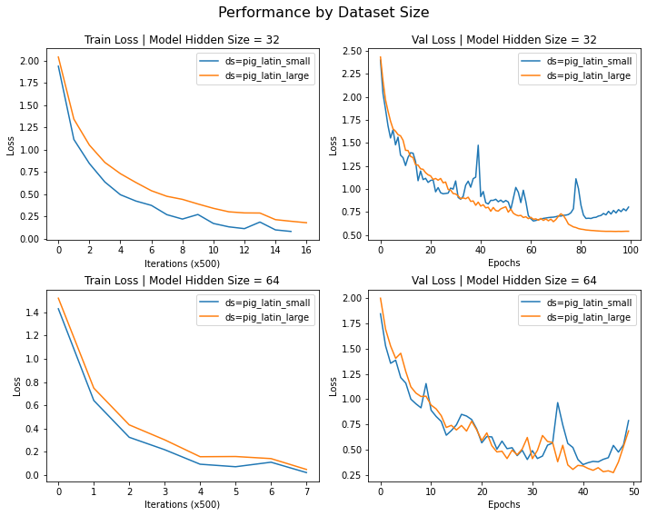

[figure not shown]

```python
save_loss_comparison_by_dataset(
    trans32_losses_s,
    trans32_losses_l,
    trans64_losses_s,
    trans64_losses_l,
    trans32_args_s,
    trans32_args_l,
    trans64_args_s,
    trans64_args_l,
    "trans_by_dataset",
)
save_loss_comparison_by_hidden(
    trans32_losses_s,
    trans32_losses_l,
    trans64_losses_s,
    trans64_losses_l,
    trans32_args_s,
    trans32_args_l,
    trans64_args_s,
    trans64_args_l,
    "trans_by_hidden",
)
```

## Part 2.2 Question 4:

Knowing that the sequence of the word in languages affects the semantic meaning, we need to represent the position of each word through this positional encoding, especially for the transformer as sequential information is not encoded. Theoretically, the advantage of using this positional encoding method is that the current method grasps the pattern from the encoding, hence generalizes better and works better for longer sentences.

## Part 2.2 Question 5:

Comparing the validation losses between RNNAttention, single-block Attention and the current decorder, the RNNAttention has the lowest validation loss out of all three and the current encoder has a smaller validation loss than the single-block Attention. The validation loss value of each method changes every time after running the code, yet the observations above hold true. I have only provided a relative comparison in the above explanations.

## Part 2.2 Question 6:

- In terms of the effect of the data size, similar to what we have obseerved in Part 1 Question 1, the generaliaztion performance is better and the validation loss is smaller as we increase the data size, this holds true for both hidden size 32 and 64.

This observation can be seen from the plot, save_loss_comparison_by_dataset.

- In terms of the effect of the model capacity, the generaliaztion performance is better and the validation loss is smaller as we increase the model capacity, that is using the hidden size 64 is better than the hidden size 32. This effect holds true for both large and small data size.

This observation can be seen from the plot, save_loss_comparison_by_hidden.